# bkg

```r
#install.packages("ggjoy")
setwd("C:\\Users\\ringa\\Desktop\\BKG")
library(arules)
library(tidyverse)
library(skimr)
library(lubridate)
#library(scale)
```

```r
train <- read_csv("booking_train_set.csv") %>% mutate(city_id = as.character(city_id))
test <- read_csv("booking_test_set.csv")
```

net <- graph_from_data_frame(d=links, vertices=nodes, directed=T) net

E(net) # The edges of the “net” object V(net) # The vertices of the “net” object E(net)$type # Edge attribute "type" V(net)$media # Vertex attribute “media”

# Find nodes and edges by attribute:

# (that returns oblects of type vertex sequence/edge sequence)

V(net)[media==“BBC”] E(net)[type==“mention”]

# You can also accesss the network matrix directly:

net[1,] net[5,7]

plot(net)

```r
train %>% head()
```

```
## # A tibble: 6 x 10
##      X1 user_id checkin    checkout   city_id device_class affiliate_id
##   <dbl>   <dbl> <date>     <date>     <chr>   <chr>               <dbl>
## 1     0 1006220 2016-04-09 2016-04-11 31114   desktop               384
## 2     1 1006220 2016-04-11 2016-04-12 39641   desktop               384
## 3     2 1006220 2016-04-12 2016-04-16 20232   desktop               384
## 4     3 1006220 2016-04-16 2016-04-17 24144   desktop               384
## 5     4 1010293 2016-07-09 2016-07-10 5325    mobile                359
## 6     5 1010293 2016-07-10 2016-07-11 55      mobile                359
## # ... with 3 more variables: booker_country <chr>, hotel_country <chr>,
## #   utrip_id <chr>
```

```r
train_IDs <- train %>% mutate(IDs = row_number()) %>% filter(hotel_country == "Phaic Tăn")
test_IDs <- test %>% mutate(IDs = row_number()) %>% filter(hotel_country == "Phaic Tăn")

train[train_IDs$IDs,"hotel_country"]<- "Phaic Tan"
test[test_IDs$IDs,"hotel_country"]<- "Phaic Tan"

train <- train %>%
  mutate(user_id = as.character(user_id),
         city_id = as.character(city_id),
         affiliate_id = as.character(affiliate_id),
         stay_days = ymd(checkout) - ymd(checkin),
         joint = str_c(booker_country,'-',hotel_country),
         checkin_month = month(checkin),
         checkin_year = year(checkin)
         )

test <- test %>%
  mutate(user_id = as.character(user_id),
         city_id = as.character(city_id),
         affiliate_id = as.character(affiliate_id),
         stay_days = ymd(checkout) - ymd(checkin),
         joint = str_c(booker_country,'-',hotel_country),
         checkin_month = month(checkin),
         checkin_year = year(checkin)
         )

train <- train %>%
  arrange(utrip_id,checkin) %>%
  group_by(utrip_id) %>%
  mutate(city_step=row_number()) %>%
  ungroup()

test <- test %>%
  arrange(utrip_id,checkin) %>%
  group_by(utrip_id) %>%
  mutate(city_step=row_number()) %>%
  ungroup()
```

```r
train
```

```
## # A tibble: 1,166,835 x 15
##         X1 user_id checkin    checkout   city_id device_class affiliate_id
##      <dbl> <chr>   <date>     <date>     <chr>   <chr>        <chr>
##  1  542546 1000027 2016-08-13 2016-08-14 8183    desktop      7168
##  2  542547 1000027 2016-08-14 2016-08-16 15626   desktop      7168
##  3  542548 1000027 2016-08-16 2016-08-18 60902   desktop      7168
##  4  542549 1000027 2016-08-18 2016-08-21 30628   desktop      253
##  5 1061281 1000033 2016-04-09 2016-04-11 38677   mobile       359
##  6 1061282 1000033 2016-04-11 2016-04-12 52089   desktop      384
##  7 1061283 1000033 2016-04-12 2016-04-14 21328   desktop      384
##  8 1061284 1000033 2016-04-14 2016-04-16 27485   desktop      384
##  9 1061285 1000033 2016-04-16 2016-04-19 38677   desktop      384
## 10   81631 1000045 2016-06-18 2016-06-20 64876   desktop      2790
## # ... with 1,166,825 more rows, and 8 more variables: booker_country <chr>,
## #   hotel_country <chr>, utrip_id <chr>, stay_days <drtn>, joint <chr>,
## #   checkin_month <dbl>, checkin_year <dbl>, city_step <int>
```

```r
train %>% names()
```

```
##  [1] "X1"             "user_id"        "checkin"        "checkout"
##  [5] "city_id"        "device_class"   "affiliate_id"   "booker_country"
##  [9] "hotel_country"  "utrip_id"       "stay_days"      "joint"
## [13] "checkin_month"  "checkin_year"   "city_step"
```

```r
train %>% head(3)
```

```
## # A tibble: 3 x 15
##       X1 user_id checkin    checkout   city_id device_class affiliate_id
##    <dbl> <chr>   <date>     <date>     <chr>   <chr>        <chr>
## 1 542546 1000027 2016-08-13 2016-08-14 8183    desktop      7168
## 2 542547 1000027 2016-08-14 2016-08-16 15626   desktop      7168
## 3 542548 1000027 2016-08-16 2016-08-18 60902   desktop      7168
## # ... with 8 more variables: booker_country <chr>, hotel_country <chr>,
## #   utrip_id <chr>, stay_days <drtn>, joint <chr>, checkin_month <dbl>,
## #   checkin_year <dbl>, city_step <int>
```

```r
test %>% names()
```

```
##  [1] "user_id"        "checkin"        "checkout"       "device_class"
##  [5] "affiliate_id"   "booker_country" "utrip_id"       "row_num"
##  [9] "total_rows"     "city_id"        "hotel_country"  "stay_days"
## [13] "joint"          "checkin_month"  "checkin_year"   "city_step"
```

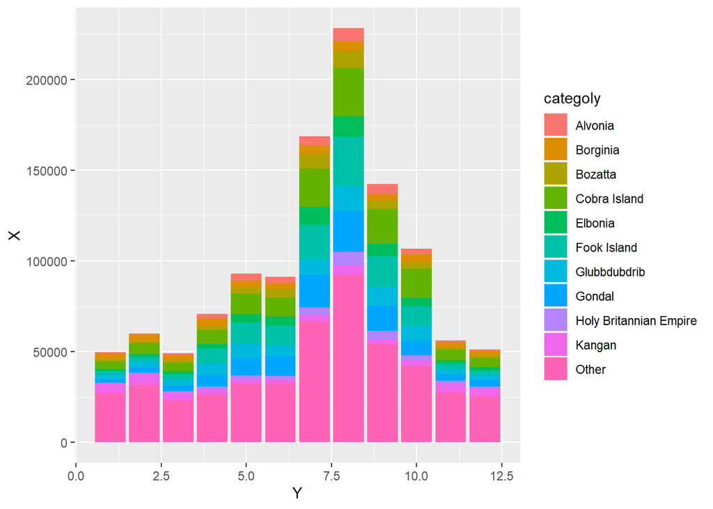

```r
train %>%
  count(hotel_country,checkin_month) %>%
  mutate(categoly = fct_lump(hotel_country, 10,w=n)) %>%
  ggplot(aes(x=checkin_month, y=n, fill = categoly)) +
  geom_col() +
  scale_y_continuous() +
  labs(y = "X",
       x = "Y")
```

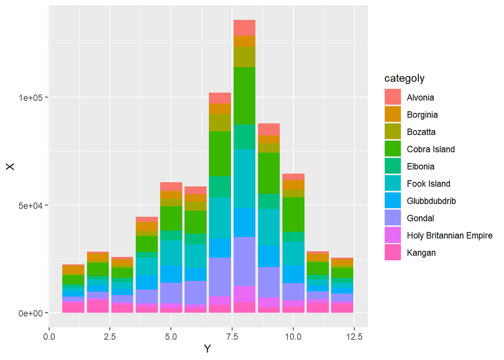

```r
train %>%
  count(hotel_country,checkin_month) %>%
  mutate(categoly = fct_lump(hotel_country, 10,w=n)) %>%
  filter(categoly != "Other") %>%
  ggplot(aes(x=checkin_month, y=n, fill = categoly)) +
  geom_col() +
  scale_y_continuous() +
  labs(y = "X",
       x = "Y")
```

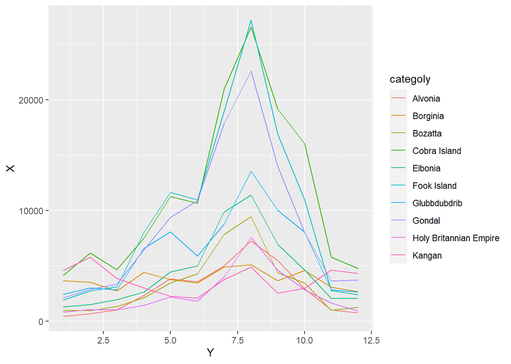

```r
train %>%
  count(hotel_country,checkin_month) %>%
  mutate(categoly = fct_lump(hotel_country, 10,w=n)) %>%
  filter(categoly != "Other") %>%
  ggplot(aes(x=checkin_month, y=n, color = categoly)) +
  geom_line() +
  scale_y_continuous() +
  labs(y = "X",
       x = "Y")
```

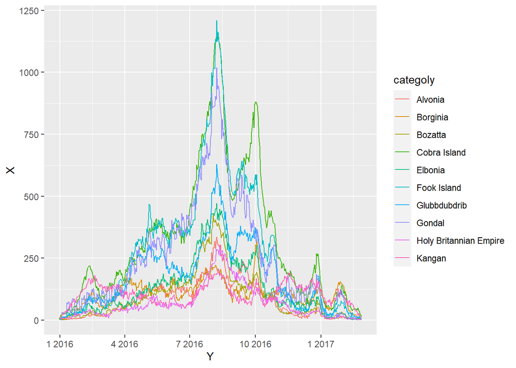

```r
train %>%
  count(hotel_country,checkin) %>%
  mutate(categoly = fct_lump(hotel_country, 10,w=n)) %>%
  filter(categoly != "Other") %>%
  ggplot(aes(x=checkin, y=n, color = categoly)) +
  geom_line() +
  scale_y_continuous() +
  labs(y = "X",
       x = "Y")
```

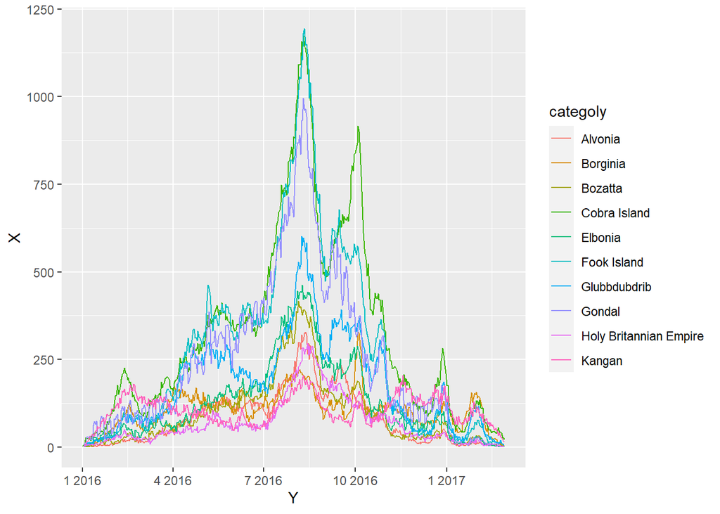

```r
train %>%
  count(hotel_country,checkout) %>%
  mutate(categoly = fct_lump(hotel_country, 10,w=n)) %>%
  filter(categoly != "Other") %>%
  ggplot(aes(x=checkout, y=n, color = categoly)) +
  geom_line() +
  scale_y_continuous() +
  labs(y = "X",
       x = "Y")
```

```r
train %>%
  head()
```

```
## # A tibble: 6 x 15
##        X1 user_id checkin    checkout   city_id device_class affiliate_id
##     <dbl> <chr>   <date>     <date>     <chr>   <chr>        <chr>
## 1  542546 1000027 2016-08-13 2016-08-14 8183    desktop      7168
## 2  542547 1000027 2016-08-14 2016-08-16 15626   desktop      7168
## 3  542548 1000027 2016-08-16 2016-08-18 60902   desktop      7168
## 4  542549 1000027 2016-08-18 2016-08-21 30628   desktop      253
## 5 1061281 1000033 2016-04-09 2016-04-11 38677   mobile       359
## 6 1061282 1000033 2016-04-11 2016-04-12 52089   desktop      384
## # ... with 8 more variables: booker_country <chr>, hotel_country <chr>,
## #   utrip_id <chr>, stay_days <drtn>, joint <chr>, checkin_month <dbl>,
## #   checkin_year <dbl>, city_step <int>
```

```r
train %>% head()
```

```
## # A tibble: 6 x 15
##        X1 user_id checkin    checkout   city_id device_class affiliate_id
##     <dbl> <chr>   <date>     <date>     <chr>   <chr>        <chr>
## 1  542546 1000027 2016-08-13 2016-08-14 8183    desktop      7168
## 2  542547 1000027 2016-08-14 2016-08-16 15626   desktop      7168
## 3  542548 1000027 2016-08-16 2016-08-18 60902   desktop      7168
## 4  542549 1000027 2016-08-18 2016-08-21 30628   desktop      253
## 5 1061281 1000033 2016-04-09 2016-04-11 38677   mobile       359
## 6 1061282 1000033 2016-04-11 2016-04-12 52089   desktop      384
## # ... with 8 more variables: booker_country <chr>, hotel_country <chr>,
## #   utrip_id <chr>, stay_days <drtn>, joint <chr>, checkin_month <dbl>,
## #   checkin_year <dbl>, city_step <int>
```

```r
library(lubridate)

dt <- train %>%
  select(checkin) %>%
  mutate( y = year(checkin))
```

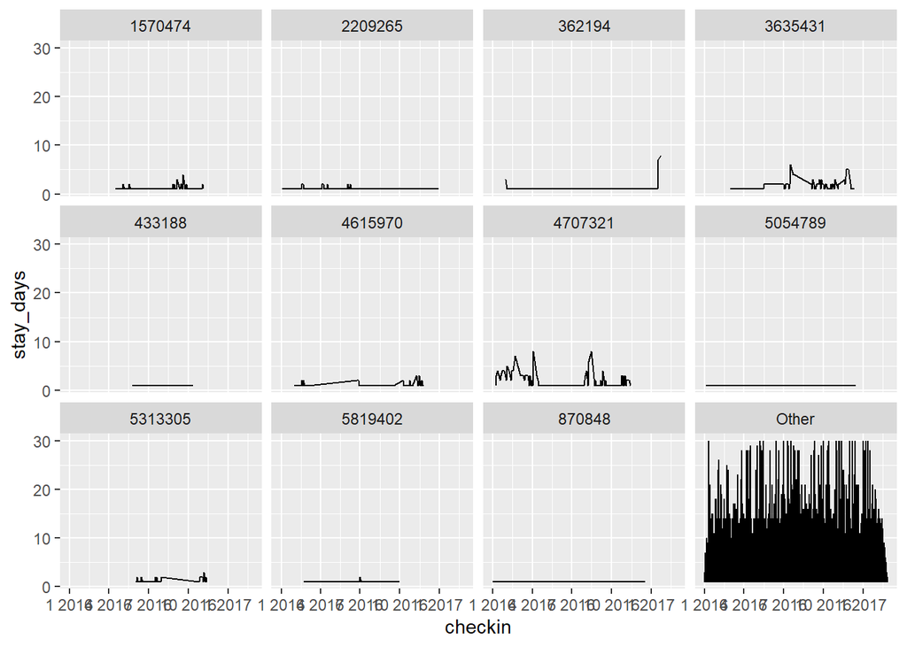

```r
train %>%
  add_count(user_id) %>%
  mutate(top_user = fct_lump(user_id, 10,w=n)) %>%
  ggplot(aes(x=checkin,y=stay_days)) +
  geom_line()+
  facet_wrap( ~top_user)
```

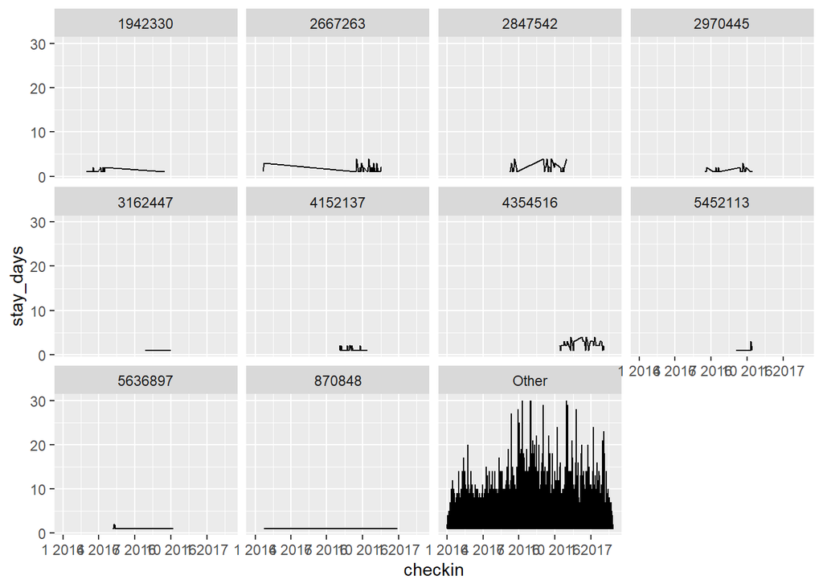

```r
test %>%
  add_count(user_id) %>%
  mutate(top_user = fct_lump(user_id, 10,w=n)) %>%
  ggplot(aes(x=checkin,y=stay_days)) +
  geom_line()+
  facet_wrap( ~top_user)
```

```r
train
```

```
## # A tibble: 1,166,835 x 15
##         X1 user_id checkin    checkout   city_id device_class affiliate_id
##      <dbl> <chr>   <date>     <date>     <chr>   <chr>        <chr>
##  1  542546 1000027 2016-08-13 2016-08-14 8183    desktop      7168
##  2  542547 1000027 2016-08-14 2016-08-16 15626   desktop      7168
##  3  542548 1000027 2016-08-16 2016-08-18 60902   desktop      7168
##  4  542549 1000027 2016-08-18 2016-08-21 30628   desktop      253
##  5 1061281 1000033 2016-04-09 2016-04-11 38677   mobile       359
##  6 1061282 1000033 2016-04-11 2016-04-12 52089   desktop      384
##  7 1061283 1000033 2016-04-12 2016-04-14 21328   desktop      384
##  8 1061284 1000033 2016-04-14 2016-04-16 27485   desktop      384
##  9 1061285 1000033 2016-04-16 2016-04-19 38677   desktop      384
## 10   81631 1000045 2016-06-18 2016-06-20 64876   desktop      2790
## # ... with 1,166,825 more rows, and 8 more variables: booker_country <chr>,
## #   hotel_country <chr>, utrip_id <chr>, stay_days <drtn>, joint <chr>,
## #   checkin_month <dbl>, checkin_year <dbl>, city_step <int>
```

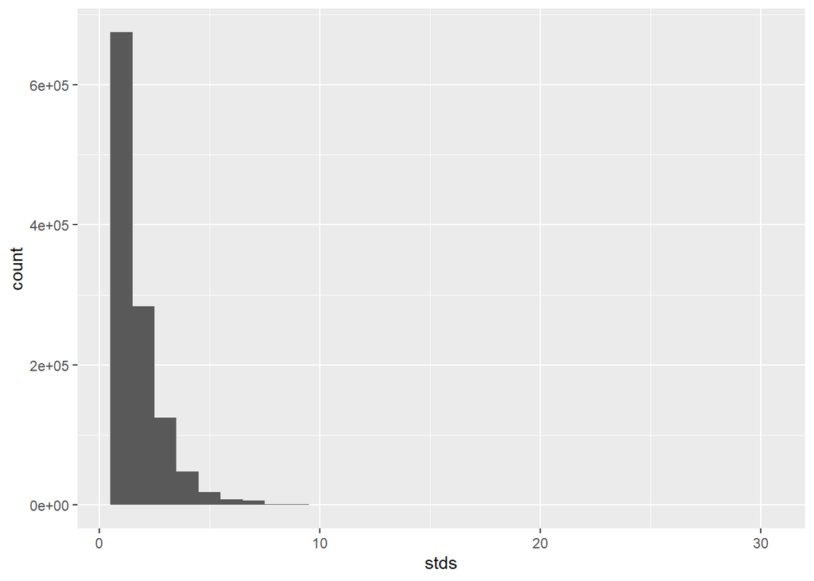

```r
train %>%
  mutate(stds = as.numeric(stay_days) ) %>%
  ggplot(aes(x=stds)) +
  geom_histogram()
```

```r
train %>%
  count(stay_days)
```

```
## # A tibble: 30 x 2
##    stay_days      n
##  * <drtn>     <int>
##  1  1 days   674542
##  2  2 days   283720
##  3  3 days   124508
##  4  4 days    47791
##  5  5 days    18296
##  6  6 days     7791
##  7  7 days     6157
##  8  8 days     1498
##  9  9 days      761
## 10 10 days      603
## # ... with 20 more rows
```

```r
train %>%
  mutate(stds = as.numeric(stay_days) ) %>%
  filter(stds == 30) %>%
  count(user_id,sort = T)
```

```
## # A tibble: 15 x 2
##    user_id     n
##    <chr>   <int>
##  1 3762669     4
##  2 4719479     2
##  3 5648237     2
##  4 1906311     1
##  5 2235612     1
##  6 2323508     1
##  7 2615059     1
##  8 3274842     1
##  9 3729044     1
## 10 4336293     1
## 11 4507708     1
## 12 5414614     1
## 13 55575       1
## 14 5934374     1
## 15 5984156     1
```

```r
train %>%
  mutate(stds = as.numeric(stay_days) ) %>%
  filter(stds == 30) %>%
  count(hotel_country,sort = T)
```

```
## # A tibble: 11 x 2
##    hotel_country     n
##    <chr>         <int>
##  1 Oceania           5
##  2 Glubbdubdrib      4
##  3 Alvonia           2
##  4 Nevoruss          2
##  5 Borginia          1
##  6 Cobra Island      1
##  7 Gondal            1
##  8 Kangan            1
##  9 Leutonia          1
## 10 Molvania          1
## 11 Yerba             1
```

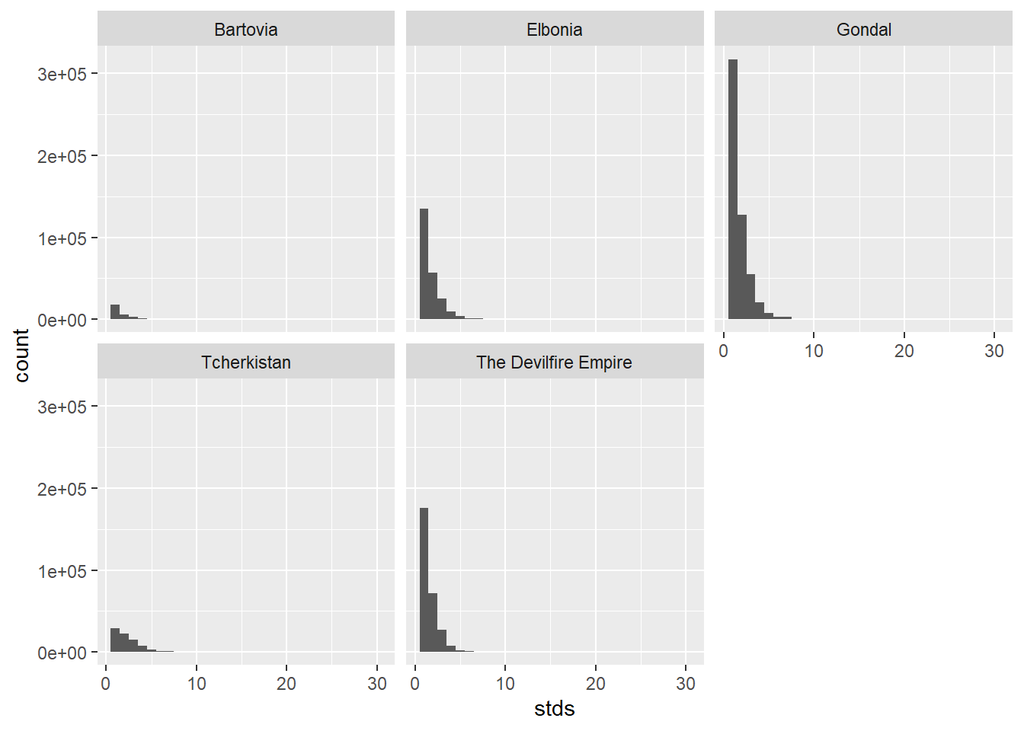

```r
train %>%
  mutate(stds = as.numeric(stay_days) ) %>%
  ggplot(aes(x=stds)) +
  geom_histogram()+
  facet_wrap(~booker_country)
```

```r
train
```

```
## # A tibble: 1,166,835 x 15
##         X1 user_id checkin    checkout   city_id device_class affiliate_id
##      <dbl> <chr>   <date>     <date>     <chr>   <chr>        <chr>
##  1  542546 1000027 2016-08-13 2016-08-14 8183    desktop      7168
##  2  542547 1000027 2016-08-14 2016-08-16 15626   desktop      7168
##  3  542548 1000027 2016-08-16 2016-08-18 60902   desktop      7168
##  4  542549 1000027 2016-08-18 2016-08-21 30628   desktop      253
##  5 1061281 1000033 2016-04-09 2016-04-11 38677   mobile       359
##  6 1061282 1000033 2016-04-11 2016-04-12 52089   desktop      384
##  7 1061283 1000033 2016-04-12 2016-04-14 21328   desktop      384
##  8 1061284 1000033 2016-04-14 2016-04-16 27485   desktop      384
##  9 1061285 1000033 2016-04-16 2016-04-19 38677   desktop      384
## 10   81631 1000045 2016-06-18 2016-06-20 64876   desktop      2790
## # ... with 1,166,825 more rows, and 8 more variables: booker_country <chr>,
## #   hotel_country <chr>, utrip_id <chr>, stay_days <drtn>, joint <chr>,
## #   checkin_month <dbl>, checkin_year <dbl>, city_step <int>
```

```r
train %>% names()
```

```
##  [1] "X1"             "user_id"        "checkin"        "checkout"
##  [5] "city_id"        "device_class"   "affiliate_id"   "booker_country"
##  [9] "hotel_country"  "utrip_id"       "stay_days"      "joint"
## [13] "checkin_month"  "checkin_year"   "city_step"
```

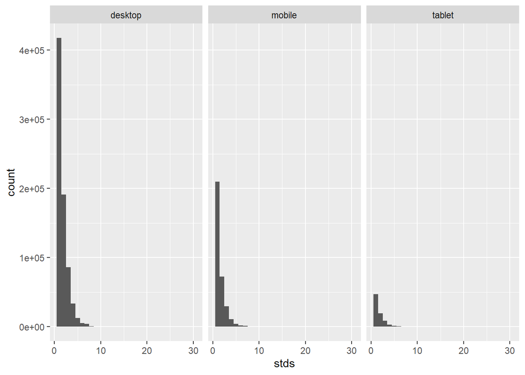

```r
train %>%
  mutate(stds = as.numeric(stay_days) ) %>%
  ggplot(aes(x=stds)) +
  geom_histogram()+
  facet_wrap(~device_class)
```

```r
train %>% count(city_step,sort = T)
```

```
## # A tibble: 48 x 2
##    city_step      n
##        <int>  <int>
##  1         1 217686
##  2         2 217573
##  3         3 217399
##  4         4 216806
##  5         5 118450
##  6         6  68596
##  7         7  41198
##  8         8  25097
##  9         9  15611
## 10        10   9837
## # ... with 38 more rows
```

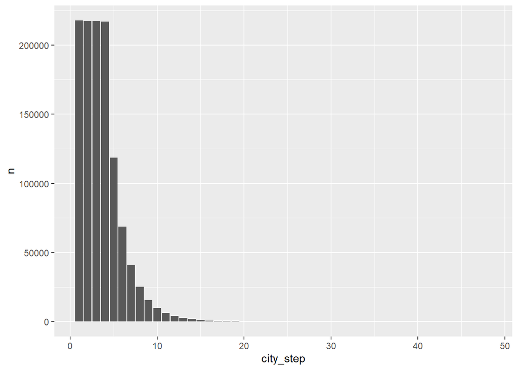

```r
train %>%
  count(city_step,sort = T) %>%
  ggplot(aes(x=city_step,y=n))+
  geom_col()
```

```r
train %>% count(user_id)
```

```
## # A tibble: 200,153 x 2
##    user_id     n
##  * <chr>   <int>
##  1 1000027     4
##  2 1000033     5
##  3 1000045     7
##  4 100008      5
##  5 1000083     4
##  6 1000097    10
##  7 1000136     5
##  8 1000145     5
##  9 100018      7
## 10 1000208     5
## # ... with 200,143 more rows
```

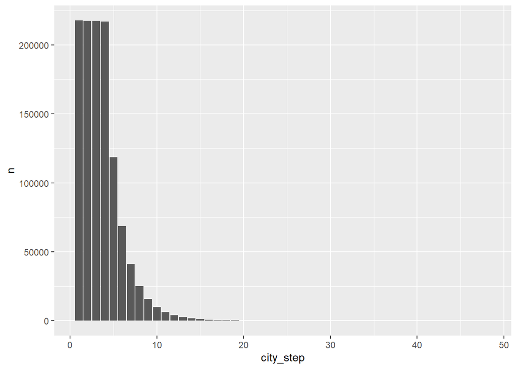

```r
train %>%
  count(city_step,sort = T) %>%
  ggplot(aes(x=city_step,y=n))+
  geom_col()
```

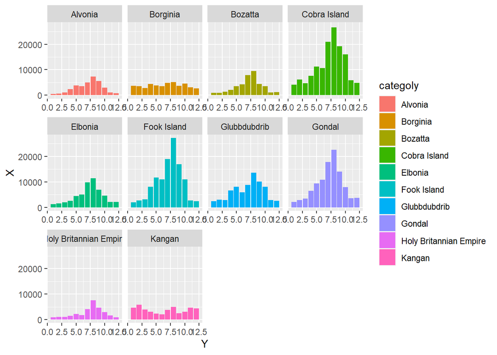

```r
train %>%
  count(hotel_country,checkin_month) %>%
  mutate(categoly = fct_lump(hotel_country, 10,w=n)) %>%
  filter(categoly != "Other") %>%
  ggplot(aes(x=checkin_month, y=n, fill = categoly)) +
  geom_col() +
  facet_wrap(~categoly,scales = "free_x")+
  scale_y_continuous() +
  labs(y = "X",
       x = "Y")
```

https://cran.r-project.org/web/packages/widyr/index.html

https://niszet.hatenablog.com/entry/2018/05/11/073000

# アイデアメモセル

comparison <- employed_cleaned %>% filter(year %in% c(2019, 2020)) %>% mutate(major_occupation = paste(industry, major_occupation, sep = " - “), minor_occupation = paste(major_occupation, minor_occupation, sep =” - ")) %>% gather(level, occupation, industry, major_occupation, minor_occupation) %>% group_by(dimension, race_gender, level, occupation, year) %>% summarize(employ_n = sum(employ_n)) %>% ungroup() %>% arrange(year) %>% group_by(dimension, level, occupation, race_gender) %>% summarize(ratio = last(employ_n) / first(employ_n), change = ratio - 1, employed_2019 = first(employ_n)) %>% group_by(dimension, level, occupation) %>% mutate(total_2019 = sum(employed_2019)) %>% ungroup()

compare_2019_2020 %>% filter(dimension == “Gender”) %>%

mutate(industry = fct_reorder(industry, change)) %>%

ggplot(aes(change, industry)) + geom_errorbarh(aes(xmin = 0, xmax = change, color = race_gender), height = 0, position = position_dodge(width = .7)) + geom_point(aes(size = employed_2019, color = race_gender), position = position_dodge(width = .7)) + geom_vline(lty = 2, xintercept = 0) +

scale_x_continuous(labels = percent) + scale_color_discrete(guide = guide_legend(reverse = TRUE)) + scale_size_continuous(labels = comma, guide = FALSE) + labs(title = “What industries suffered the most in 2020?”, subtitle = “Size of point represents # employed in industry in 2019”, x = “Shift in # employed from 2019 to 2020 (BLS)”, y = "“, color =”Gender“, size =”# employed 2019")

library(ggrepel) compare_2019_2020 %>% filter(dimension == “Total”) %>% mutate(industry = fct_reorder(industry, change)) %>% ggplot(aes(employed_2019, change)) + geom_point() + geom_text_repel(aes(label = industry)) + geom_hline(lty = 2, yintercept = 0) + scale_x_continuous(labels = comma) + scale_y_continuous(labels = percent)

# 変数の定義

Dataset

The training dataset consists of over a million of anonymized hotel reservations, based on real data, with the following features:

user_id - User ID  
check-in - Reservation check-in date(予約チェックイン)  
checkout - Reservation check-out date（予約チェックアウト）  
affiliate_id - （予約者のアクセス元サイト？？）  
An anonymized ID of affiliate channels where the booker came from  
(e.g. direct, some third party referrals, paid search engine, etc.)

device_class - desktop/mobile（アクセスデバイス・端末）

booker_country - （予約してきたヒトの国？デバイスの位置的な？）  
Country from which the reservation was made (anonymized)

hotel_country - （ホテルの国）Country of the hotel (anonymized)  
city_id - （ホテルの都市）city_id of the hotel’s city (anonymized)

utrip_id - （旅行目的をグループワケした？？）  
Unique identification of user’s trip  
(a group of multi-destinations bookings within the same trip) 同一旅行内の複数の目的地を予約するグループ

The evaluation dataset is constructed similarly,  
however the city_id of the final reservation of each trip is concealed and requires a prediction.

testの時はcity ID は隠されているらしい  
コレの予測がタスクらしい

# 分析対称の洗い出し

1-アクセス国と、対称国の関係 （フランス人は京都がお好き、みたいな）  
2-常連客がどの国、どの町を予約するか （ほとんど決定論的に決まるなら固定でいいやん？）  
3-旅行目的区分とホテルの国、cityの結びつき （この目的のヒトはこの国行きやすいとか）

前処理、時刻変換と滞在期間変数を作成  
4-チェックイン・チェックアウトから、平均滞在期間と町、国の関係  
5-滞在期間と、予約者の国の関係(バケーション取りやすいとか？裏山)  
6-滞在期間と、予約対象国の関係（北極なら少なくとも1週間くらい取るよね、とか）

追加予定：

南半球、北半球の関係  
予約者と予約対象国とのフライトにかかる平均時間を変数として追加するとか  
フライトでなくても単純に距離計算でも。

もし、予約してきたヒトが所属国アメリカになっていたとしても、デバイスの元がフランスとかだったら、  
既にフランスに移住してるかもだから、  
そこの判断基準どうするか決めて、「本当の所属国」みたいなの出したら使えるかも。

そもそも、どの国に宿泊施設が多いのか（ホテル大国（意味深））  
全体で見たらどの程度の人が、何月に行くのか（寒い国の人が暖かい国に行くとか）

# 例外で探る

```r
train %>% select(checkin) %>% arrange(checkin) %>% head(3)
```

```
## # A tibble: 3 x 1
##   checkin
##   <date>
## 1 2015-12-31
## 2 2015-12-31
## 3 2015-12-31
```

```r
train %>% select(checkin) %>% arrange(desc(checkin)) %>% head(3)
```

```
## # A tibble: 3 x 1
##   checkin
##   <date>
## 1 2017-02-27
## 2 2017-02-27
## 3 2017-02-27
```

```r
train %>% group_by(user_id) %>% summarise(coun = n()) %>% arrange(desc(coun))
```

```
## # A tibble: 200,153 x 2
##    user_id  coun
##    <chr>   <int>
##  1 2209265   172
##  2 870848    137
##  3 3635431   123
##  4 362194    102
##  5 5819402    94
##  6 1570474    79
##  7 4707321    76
##  8 433188     70
##  9 5054789    68
## 10 4615970    63
## # ... with 200,143 more rows
```

これってテストと被るのが何人くらいいるのか  
それによってユーザIDの重要性が異なる  
再登場なしなら、単純に旅行する国の順番を考えれば良くなる  
マルコフ連鎖というか、条件確率というか。単純言語生成みたいな

このカウント数はユーザーが一回のutripで複数回っても大きくなるし、複数回に分けて旅行しても大きくなる

一回の旅行でカウントしたければutrip id でグループ

```r
train %>% group_by(user_id,utrip_id) %>% summarise(coun = n()) %>% arrange(desc(coun))
```

```
## # A tibble: 217,686 x 3
## # Groups:   user_id [200,153]
##    user_id utrip_id    coun
##    <chr>   <chr>      <int>
##  1 3635431 3635431_3     48
##  2 2209265 2209265_10    45
##  3 433188  433188_8      44
##  4 2209265 2209265_15    41
##  5 5231140 5231140_3     41
##  6 2899950 2899950_1     39
##  7 3422831 3422831_1     39
##  8 3878245 3878245_1     39
##  9 1380626 1380626_3     36
## 10 3611727 3611727_3     36
## # ... with 217,676 more rows
```

このサマリはユーザーが各旅行で何か所の町をまわったか、というサマリになる  
つまり、一回の旅行で滅茶苦茶観光地をうつるユーザーが見つけられる

あまりに多い町数になっているユーザーは世界一周詰め込みタイプと名づける

ただし、この表示方法だと世界一周に1回いっただけで、ほかの旅行はそんなに回らない  
というヒトもいるかもしれないので注意

もうちょっと国まで掘る

```r
train %>% group_by(user_id,utrip_id, hotel_country) %>% summarise(coun = n()) %>% arrange(desc(coun))
```

```
## # A tibble: 307,828 x 4
## # Groups:   user_id, utrip_id [217,686]
##    user_id utrip_id   hotel_country         coun
##    <chr>   <chr>      <chr>                <int>
##  1 3635431 3635431_3  Gondal                  48
##  2 2209265 2209265_10 The Devilfire Empire    45
##  3 433188  433188_8   Elbonia                 44
##  4 3422831 3422831_1  Kasnia                  39
##  5 2899950 2899950_1  Patusan                 38
##  6 3611727 3611727_3  Oceania                 36
##  7 362194  362194_12  Bahavia                 36
##  8 5231140 5231140_3  Glubbdubdrib            35
##  9 1481929 1481929_2  Kumbolaland             34
## 10 1765701 1765701_3  Cobra Island            33
## # ... with 307,818 more rows
```

ユーザー毎に並べたい

```r
train %>%
  group_by(user_id,utrip_id, hotel_country) %>%
  summarise(coun = n()) %>%
  arrange(user_id,desc(coun))
```

```
## # A tibble: 307,828 x 4
## # Groups:   user_id, utrip_id [217,686]
##    user_id utrip_id  hotel_country  coun
##    <chr>   <chr>     <chr>         <int>
##  1 1000027 1000027_1 Gondal            4
##  2 1000033 1000033_1 Cobra Island      5
##  3 1000045 1000045_1 Fook Island       3
##  4 1000045 1000045_1 Carpathia         2
##  5 1000045 1000045_1 Gondal            2
##  6 100008  100008_1  Kamistan          5
##  7 1000083 1000083_1 Osterlich         3
##  8 1000083 1000083_1 Gondal            1
##  9 1000097 1000097_1 Fook Island      10
## 10 1000136 1000136_1 Fook Island       5
## # ... with 307,818 more rows
```

年中旅行しているヒトを調べるために  
さらにカウントを付ける

```r
train %>%
  group_by(user_id,utrip_id) %>%
  summarise(coun = n()) %>%
  group_by(user_id) %>%
  summarise(coun = n()) %>%
  arrange(desc(coun))
```

```
## # A tibble: 200,153 x 2
##    user_id  coun
##    <chr>   <int>
##  1 870848     20
##  2 5054789    17
##  3 3760195    15
##  4 341743     13
##  5 384105     11
##  6 4349469    11
##  7 5819402    11
##  8 2209265    10
##  9 3726000    10
## 10 1068616     9
## # ... with 200,143 more rows
```

これでユーザー毎に201512-201702までの間に何回旅行したかが分かる  
約位一年ちょっとで10回以上の人たちは、殆ど毎月旅行に行くようなスナフキン族だと考えられる

```r
train
```

```
## # A tibble: 1,166,835 x 15
##         X1 user_id checkin    checkout   city_id device_class affiliate_id
##      <dbl> <chr>   <date>     <date>     <chr>   <chr>        <chr>
##  1  542546 1000027 2016-08-13 2016-08-14 8183    desktop      7168
##  2  542547 1000027 2016-08-14 2016-08-16 15626   desktop      7168
##  3  542548 1000027 2016-08-16 2016-08-18 60902   desktop      7168
##  4  542549 1000027 2016-08-18 2016-08-21 30628   desktop      253
##  5 1061281 1000033 2016-04-09 2016-04-11 38677   mobile       359
##  6 1061282 1000033 2016-04-11 2016-04-12 52089   desktop      384
##  7 1061283 1000033 2016-04-12 2016-04-14 21328   desktop      384
##  8 1061284 1000033 2016-04-14 2016-04-16 27485   desktop      384
##  9 1061285 1000033 2016-04-16 2016-04-19 38677   desktop      384
## 10   81631 1000045 2016-06-18 2016-06-20 64876   desktop      2790
## # ... with 1,166,825 more rows, and 8 more variables: booker_country <chr>,
## #   hotel_country <chr>, utrip_id <chr>, stay_days <drtn>, joint <chr>,
## #   checkin_month <dbl>, checkin_year <dbl>, city_step <int>
```

単純なcity id の登場回数

```r
train %>% count(city_id) %>% arrange(desc(n))
```

```
## # A tibble: 39,901 x 2
##    city_id     n
##    <chr>   <int>
##  1 47499   11242
##  2 23921   10511
##  3 36063    9559
##  4 17013    9011
##  5 29319    8179
##  6 64876    7784
##  7 55128    7763
##  8 17127    6893
##  9 2416     6641
## 10 66648    6625
## # ... with 39,891 more rows
```

テストの中に同じ常連さんはいるのか

```r
test %>% filter(user_id %in% unique(train$user_id)) %>% count(user_id) %>% arrange(desc(n))
```

```
## # A tibble: 9,496 x 2
##    user_id     n
##    <chr>   <int>
##  1 4152137    60
##  2 2667263    46
##  3 3162447    44
##  4 1942330    43
##  5 870848     40
##  6 2970445    38
##  7 1482089    34
##  8 158140     34
##  9 2253433    32
## 10 1125218    31
## # ... with 9,486 more rows
```

ちゃんとおるね  
極論すると、この重複ユーザーはtrainからの旅行の傾向を掴むことができれば予測の可能性が見えてくる

ただし、いないヒトたちをどう扱うかが問題  
クリック予想のタスクとか使えそう

以下はユーザーの訪れた町数と、重複をカウントした列

```r
train %>%
  group_by(user_id,city_id) %>%
  summarise(coun = n()) %>%
  group_by(user_id) %>%
  summarise(visit_city_num = n(), sums_vis_city= sum(coun)) %>%
  arrange(desc(visit_city_num),user_id)
```

```
## # A tibble: 200,153 x 3
##    user_id visit_city_num sums_vis_city
##    <chr>            <int>         <int>
##  1 1570474             72            79
##  2 4707321             67            76
##  3 5054789             61            68
##  4 5313305             61            63
##  5 1380626             54            60
##  6 5906175             52            60
##  7 5771132             51            58
##  8 6004567             50            59
##  9 2584362             47            49
## 10 341743              47            54
## # ... with 200,143 more rows
```

```r
train %>% count(user_id,utrip_id) %>% arrange(reorder(user_id,desc(n)),desc(n))
```

[output not shown]

10ページくらいの3635431が複数のutrip idを持っていた。分割して旅行している。

```r
train %>% filter(user_id == "3635431") %>% group_by(utrip_id,city_id) %>% summarise(coun = n())
```

```
## # A tibble: 19 x 3
## # Groups:   utrip_id [6]
##    utrip_id   city_id  coun
##    <chr>      <chr>   <int>
##  1 3635431_1  36063       6
##  2 3635431_1  47319       2
##  3 3635431_1  63784       2
##  4 3635431_10 22561       3
##  5 3635431_10 27920       1
##  6 3635431_10 28962       7
##  7 3635431_10 3109        5
##  8 3635431_10 36063      12
##  9 3635431_10 6791        5
## 10 3635431_12 22561       1
## 11 3635431_12 36063       8
## 12 3635431_12 41265       3
## 13 3635431_3  3109        6
## 14 3635431_3  36063      26
## 15 3635431_3  43217      14
## 16 3635431_3  47319       2
## 17 3635431_7  3109       13
## 18 3635431_9  3109        6
## 19 3635431_9  36063       1
```

旅行プランの偏りが気になってきた  
どんな順序でまわるの？  
月によって人気な国とか町はあるか

```r
length(unique(train$city_id))
```

```
## [1] 39901
```

```r
length(unique(train$hotel_country))
```

```
## [1] 195
```

多すぎるからすこし減らしたい

```r
train %>%
  count(hotel_country) %>%
  filter(n > 20)
```

```
## # A tibble: 138 x 2
##    hotel_country                      n
##    <chr>                          <int>
##  1 Absurdistan                       74
##  2 Aldorria                         409
##  3 Aldovia                        12887
##  4 Altis and Stratis, Republic of   968
##  5 Alvonia                        34446
##  6 Angrezi Raj                       25
##  7 Aslerfan                        3254
##  8 Atlantis                        4265
##  9 Axphain                        28719
## 10 Bacteria                         451
## # ... with 128 more rows
```

```r
comp_month <- train %>%
  group_by(hotel_country,checkin_month) %>%
  summarise(coun = n()) %>%
  complete(hotel_country,checkin_month) %>%
  arrange(hotel_country,checkin_month) %>%
  count(hotel_country) %>%
  filter(n==12)
train %>%
  filter(hotel_country %in% unique(comp_month$hotel_country)) %>%
  group_by(hotel_country,checkin_month) %>%
  summarise(coun = n()) %>%
  complete(hotel_country,checkin_month) %>%
  arrange(hotel_country,checkin_month)
```

```
## # A tibble: 1,248 x 3
## # Groups:   hotel_country [104]
##    hotel_country checkin_month  coun
##    <chr>                 <dbl> <int>
##  1 Absurdistan               1     1
##  2 Absurdistan               2     1
##  3 Absurdistan               3     3
##  4 Absurdistan               4     1
##  5 Absurdistan               5     5
##  6 Absurdistan               6     8
##  7 Absurdistan               7    19
##  8 Absurdistan               8    17
##  9 Absurdistan               9     5
## 10 Absurdistan              10     5
## # ... with 1,238 more rows
```

```r
library(ggjoy)
```

```r
if(0){

for(i in 1:length(unique(comp_month$hotel_country))){

train %>%
  filter(hotel_country %in% unique(comp_month$hotel_country)) %>%
  group_by(hotel_country,checkin_month) %>%
  summarise(coun = n()) %>%
  complete(hotel_country,checkin_month) %>%
  arrange(hotel_country,checkin_month) %>%
  filter(hotel_country == unique(comp_month$hotel_country)[i]) %>%
ggplot(aes(x=checkin_month, y=coun)) +
  geom_bar(stat="identity")+
  ggtitle(unique(comp_month$hotel_country)[i])

ggsave(str_c("month//",unique(comp_month$hotel_country)[i],".png"))

}


}
```

city id でも12か月コンプしているものをつかってみる

```r
comp_month_city <- train %>%
  mutate(comb = str_c(city_id,hotel_country)) %>%
  group_by(comb,checkin_month) %>%
  summarise(coun = n())%>%
  count(comb) %>%
  filter(n==12)
train %>%
  mutate(comb = str_c(city_id,hotel_country)) %>%
  filter(comb %in% unique(comp_month_city$comb)) %>%
  group_by(comb,checkin_month) %>%
  summarise(coun = n()) %>%
  #complete(comb,checkin_month) %>%
  arrange(comb,checkin_month)
```

```
## # A tibble: 19,944 x 3
## # Groups:   comb [1,662]
##    comb              checkin_month  coun
##    <chr>                     <dbl> <int>
##  1 10016Cobra Island             1     1
##  2 10016Cobra Island             2     1
##  3 10016Cobra Island             3     1
##  4 10016Cobra Island             4     2
##  5 10016Cobra Island             5     6
##  6 10016Cobra Island             6     4
##  7 10016Cobra Island             7     6
##  8 10016Cobra Island             8     6
##  9 10016Cobra Island             9     4
## 10 10016Cobra Island            10     4
## # ... with 19,934 more rows
```

```r
if(0){

for(i in 1:length(unique(comp_month_city$comb))){

  train %>%
  mutate(comb = str_c(city_id,hotel_country)) %>%
  filter(comb %in% unique(comp_month_city$comb)) %>%
  group_by(comb,checkin_month) %>%
  summarise(coun = n()) %>%
  #complete(comb,checkin_month) %>%
  arrange(comb,checkin_month) %>%
  filter(comb == unique(comp_month_city$comb)[i]) %>%
  ggplot(aes(x=checkin_month, y=coun)) +
  geom_bar(stat="identity")+
  ggtitle(unique(comp_month_city$comb)[i])

ggsave(str_c("city//",unique(comp_month_city$comb)[i],".png"))

}


}
```

```r
train %>%
  group_by(hotel_country,checkin_month) %>%
  summarise(coun = n()) %>%
  arrange(hotel_country,checkin_month) %>%
  select(hotel_country) %>% unique()
```

```
## # A tibble: 195 x 1
## # Groups:   hotel_country [195]
##    hotel_country
##    <chr>
##  1 Absurdistan
##  2 Aldorria
##  3 Aldovia
##  4 Almaigne
##  5 Altis and Stratis, Republic of
##  6 Alvonia
##  7 Angrezi Raj
##  8 Aslerfan
##  9 Atlantis
## 10 Axphain
## # ... with 185 more rows
```

仕事でやるとか、本気で賞狙いに行くなら各国の傾向深ぼれば良いと思います

一回や二回しか登場しない国は重要視する必要があるのか？  
これが鍵となって一連の旅行パターンが組まれているとか？

それも含めて、utrip idを一つのユニークとして考えた時のマーケットバスケット（アプリオリ）でもしてみるか

```r
train %>%
  count(hotel_country) %>%
  arrange(n)
```

```
## # A tibble: 195 x 2
##    hotel_country     n
##    <chr>         <int>
##  1 Buenaventura      1
##  2 Guilder           1
##  3 Maltovia          1
##  4 Medici            1
##  5 New Germany       1
##  6 Norteguay         1
##  7 Nuevo Rico        1
##  8 Rhelasia          1
##  9 Sardovia          1
## 10 Utopia            1
## # ... with 185 more rows
```

```r
train %>% head()
```

```
## # A tibble: 6 x 15
##        X1 user_id checkin    checkout   city_id device_class affiliate_id
##     <dbl> <chr>   <date>     <date>     <chr>   <chr>        <chr>
## 1  542546 1000027 2016-08-13 2016-08-14 8183    desktop      7168
## 2  542547 1000027 2016-08-14 2016-08-16 15626   desktop      7168
## 3  542548 1000027 2016-08-16 2016-08-18 60902   desktop      7168
## 4  542549 1000027 2016-08-18 2016-08-21 30628   desktop      253
## 5 1061281 1000033 2016-04-09 2016-04-11 38677   mobile       359
## 6 1061282 1000033 2016-04-11 2016-04-12 52089   desktop      384
## # ... with 8 more variables: booker_country <chr>, hotel_country <chr>,
## #   utrip_id <chr>, stay_days <drtn>, joint <chr>, checkin_month <dbl>,
## #   checkin_year <dbl>, city_step <int>
```

```r
train %>%
  head(50) %>%
  select(city_id) %>%
  unique()
```

```
## # A tibble: 46 x 1
##    city_id
##    <chr>
##  1 8183
##  2 15626
##  3 60902
##  4 30628
##  5 38677
##  6 52089
##  7 21328
##  8 27485
##  9 64876
## 10 55128
## # ... with 36 more rows
```

```r
train %>%
  head(50) %>%
  select(utrip_id,city_id,checkin)%>%
  filter(utrip_id=="1010293_1")
```

```
## # A tibble: 0 x 3
## # ... with 3 variables: utrip_id <chr>, city_id <chr>, checkin <date>
```

```r
if(0){

dat <-
  data.table(

    train %>%
  select(utrip_id,city_id) %>%
  group_by(utrip_id,city_id) %>%
  summarise(vv = n(),.groups = 'drop')%>%
  complete(utrip_id,city_id,fill = list(vv=0))%>%
  pivot_wider(names_from=city_id, values_from = vv)
)

}
```

```r
just_1 <- train %>%
  group_by(utrip_id) %>%
  summarise(coun=n()) %>%
  filter(coun == 1) %>%
  select(utrip_id) %>%
  unique()
```

```r
train %>%
  filter(utrip_id %in% just_1$utrip_id) %>%
  count(hotel_country)
```

```
## # A tibble: 40 x 2
##    hotel_country     n
##  * <chr>         <int>
##  1 Aldovia           2
##  2 Alvonia           2
##  3 Atlantis          1
##  4 Axphain           6
##  5 Bandaria          1
##  6 Bartovia          2
##  7 Borginia          4
##  8 Bozatta           6
##  9 Carjackistan      2
## 10 Carpathia         3
## # ... with 30 more rows
```

```r
train %>%
  filter(utrip_id %in% just_1$utrip_id) %>%
  count(booker_country)
```

```
## # A tibble: 4 x 2
##   booker_country           n
## * <chr>                <int>
## 1 Elbonia                 41
## 2 Gondal                  43
## 3 Tcherkistan              2
## 4 The Devilfire Empire    27
```

```r
train %>%
  filter(utrip_id %in% just_1$utrip_id) %>%
  count(user_id)
```

```
## # A tibble: 113 x 2
##    user_id     n
##  * <chr>   <int>
##  1 1032416     1
##  2 1109803     1
##  3 1123848     1
##  4 1144248     1
##  5 1204872     1
##  6 1219694     1
##  7 1328507     1
##  8 1329518     1
##  9 1375406     1
## 10 1491897     1
## # ... with 103 more rows
```

```r
just_1 <- train %>%
  group_by(utrip_id) %>%
  summarise(coun=n()) %>%
  filter(coun < 20 ) %>%
  select(utrip_id) %>%
  unique()
```

```r
train %>%
  filter(utrip_id %in% just_1$utrip_id) %>%
  count(hotel_country)
```

```
## # A tibble: 195 x 2
##    hotel_country                      n
##  * <chr>                          <int>
##  1 Absurdistan                       73
##  2 Aldorria                         409
##  3 Aldovia                        12852
##  4 Almaigne                           7
##  5 Altis and Stratis, Republic of   968
##  6 Alvonia                        34366
##  7 Angrezi Raj                       25
##  8 Aslerfan                        3242
##  9 Atlantis                        4239
## 10 Axphain                        28670
## # ... with 185 more rows
```

```r
train %>%
  filter(utrip_id %in% just_1$utrip_id) %>%
  count(booker_country)
```

```
## # A tibble: 5 x 2
##   booker_country            n
## * <chr>                 <int>
## 1 Bartovia              28592
## 2 Elbonia              234474
## 3 Gondal               534160
## 4 Tcherkistan           80370
## 5 The Devilfire Empire 284073
```

```r
train %>%
  filter(utrip_id %in% just_1$utrip_id) %>%
  count(user_id)
```

```
## # A tibble: 200,017 x 2
##    user_id     n
##  * <chr>   <int>
##  1 1000027     4
##  2 1000033     5
##  3 1000045     7
##  4 100008      5
##  5 1000083     4
##  6 1000097    10
##  7 1000136     5
##  8 1000145     5
##  9 100018      7
## 10 1000208     5
## # ... with 200,007 more rows
```

```r
train %>%
  group_by(user_id,utrip_id) %>%
  summarise(n = n(),.groups = "drop") %>%
  arrange(desc(n)) %>%
  group_by(user_id) %>%
  summarise(n=sum(n)) %>%
  arrange(desc(n))
```

```
## # A tibble: 200,153 x 2
##    user_id     n
##    <chr>   <int>
##  1 2209265   172
##  2 870848    137
##  3 3635431   123
##  4 362194    102
##  5 5819402    94
##  6 1570474    79
##  7 4707321    76
##  8 433188     70
##  9 5054789    68
## 10 4615970    63
## # ... with 200,143 more rows
```

```r
train %>%
  filter(user_id == "2209265")
```

```
## # A tibble: 172 x 15
##        X1 user_id checkin    checkout   city_id device_class affiliate_id
##     <dbl> <chr>   <date>     <date>     <chr>   <chr>        <chr>
##  1 514991 2209265 2016-04-26 2016-04-27 58974   mobile       359
##  2 514992 2209265 2016-04-27 2016-04-28 58974   mobile       359
##  3 514993 2209265 2016-04-28 2016-04-29 58974   mobile       359
##  4 514994 2209265 2016-04-29 2016-04-30 58974   mobile       359
##  5 514995 2209265 2016-04-30 2016-05-01 58974   mobile       359
##  6 514996 2209265 2016-05-01 2016-05-02 58974   mobile       359
##  7 514997 2209265 2016-05-02 2016-05-03 58974   mobile       359
##  8 514998 2209265 2016-05-03 2016-05-04 58974   mobile       359
##  9 514999 2209265 2016-05-04 2016-05-05 58974   mobile       359
## 10 515000 2209265 2016-05-05 2016-05-06 58974   mobile       359
## # ... with 162 more rows, and 8 more variables: booker_country <chr>,
## #   hotel_country <chr>, utrip_id <chr>, stay_days <drtn>, joint <chr>,
## #   checkin_month <dbl>, checkin_year <dbl>, city_step <int>
```

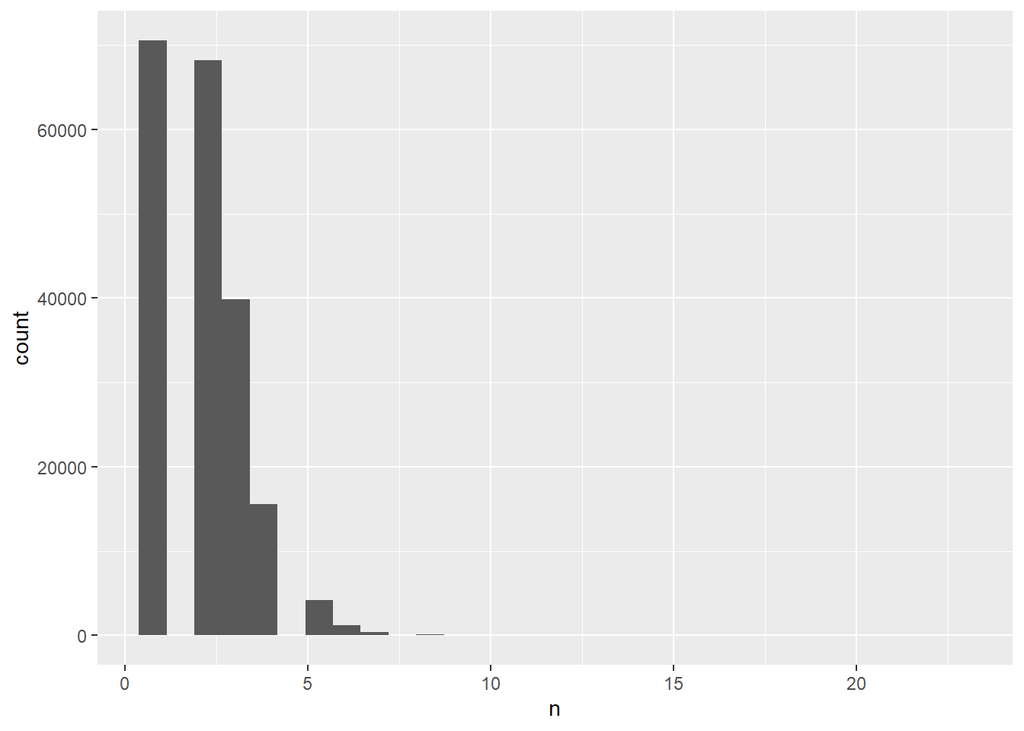

```r
train %>%
  distinct(user_id,affiliate_id) %>%
  group_by(user_id) %>%
  summarise(n = n(), .groups = "drop") %>%
  ggplot(aes(x=n))+
  geom_histogram()
```

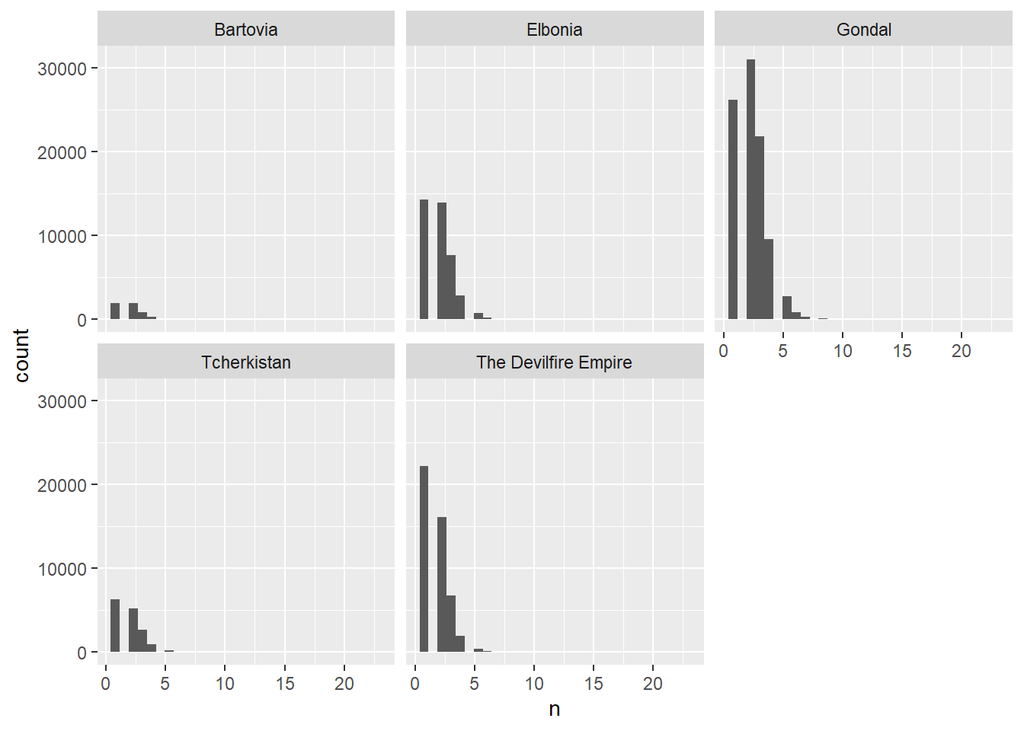

```r
train %>%
  distinct(user_id,booker_country,affiliate_id) %>%
  group_by(user_id,booker_country) %>%
  summarise(n = n(), .groups = "drop") %>%
  ggplot(aes(x=n))+
  geom_histogram()+
  facet_wrap( ~ booker_country)
```

```r
train %>% filter(utrip_id %in% just_1$utrip_id) %>% count(booker_country)
```

```
## # A tibble: 5 x 2
##   booker_country            n
## * <chr>                 <int>
## 1 Bartovia              28592
## 2 Elbonia              234474
## 3 Gondal               534160
## 4 Tcherkistan           80370
## 5 The Devilfire Empire 284073
```

```r
train %>% filter(utrip_id %in% just_1$utrip_id) %>% count(city_id)
```

```
## # A tibble: 39,813 x 2
##    city_id     n
##  * <chr>   <int>
##  1 10001       1
##  2 10002       7
##  3 10005       2
##  4 10006       2
##  5 10007      14
##  6 10009       1
##  7 1001       19
##  8 10010       2
##  9 10012       7
## 10 10013      31
## # ... with 39,803 more rows
```

```r
train %>% filter(utrip_id %in% just_1$utrip_id) %>% count(user_id)
```

```
## # A tibble: 200,017 x 2
##    user_id     n
##  * <chr>   <int>
##  1 1000027     4
##  2 1000033     5
##  3 1000045     7
##  4 100008      5
##  5 1000083     4
##  6 1000097    10
##  7 1000136     5
##  8 1000145     5
##  9 100018      7
## 10 1000208     5
## # ... with 200,007 more rows
```

デバイスと宿泊期間に違いとか在ったりするかな？  
あと宿泊サイトによっては長期を推奨するプランが在ったりとか？

```r
train %>% filter(utrip_id %in% just_1$utrip_id) %>% count(device_class)
```

```
## # A tibble: 3 x 2
##   device_class      n
## * <chr>         <int>
## 1 desktop      750962
## 2 mobile       329904
## 3 tablet        80803
```

```r
train %>% filter(utrip_id %in% just_1$utrip_id) %>% count(affiliate_id)
```

```
## # A tibble: 3,253 x 2
##    affiliate_id     n
##  * <chr>        <int>
##  1 100             11
##  2 1000             2
##  3 10000            1
##  4 10001          611
##  5 10007            3
##  6 10009            1
##  7 1001             1
##  8 10010            1
##  9 10020            1
## 10 10029          146
## # ... with 3,243 more rows
```

```r
train %>% filter(utrip_id %in% just_1$utrip_id) %>% count(checkin_month)
```

```
## # A tibble: 12 x 2
##    checkin_month      n
##  *         <dbl>  <int>
##  1             1  49556
##  2             2  59846
##  3             3  48976
##  4             4  70493
##  5             5  92485
##  6             6  90746
##  7             7 167900
##  8             8 227507
##  9             9 141437
## 10            10 106070
## 11            11  55798
## 12            12  50855
```

一回しか登場してないようなcityは予測できなくない？  
他の変数と特別な関係持ってたりする？

```r
just_1_city <- train %>% group_by(city_id) %>% summarise(coun=n()) %>% filter(coun == 1)

train %>% filter(city_id %in% just_1_city$city_id) %>% count(city_id)
```

```
## # A tibble: 12,045 x 2
##    city_id     n
##  * <chr>   <int>
##  1 10001       1
##  2 10009       1
##  3 10014       1
##  4 10018       1
##  5 10035       1
##  6 10038       1
##  7 10040       1
##  8 10051       1
##  9 10052       1
## 10 10054       1
## # ... with 12,035 more rows
```

```r
train %>% filter(city_id %in% just_1_city$city_id) %>% count(booker_country)
```

```
## # A tibble: 5 x 2
##   booker_country           n
## * <chr>                <int>
## 1 Bartovia               715
## 2 Elbonia               4042
## 3 Gondal                5937
## 4 Tcherkistan            295
## 5 The Devilfire Empire  1056
```

```r
train %>% filter(city_id %in% just_1_city$city_id) %>% count(hotel_country)
```

```
## # A tibble: 163 x 2
##    hotel_country                      n
##  * <chr>                          <int>
##  1 Absurdistan                        7
##  2 Aldorria                          10
##  3 Aldovia                           84
##  4 Altis and Stratis, Republic of     4
##  5 Alvonia                          196
##  6 Aslerfan                          50
##  7 Atlantis                         106
##  8 Axphain                          211
##  9 Bacteria                          13
## 10 Bahari                             6
## # ... with 153 more rows
```

```r
train %>% filter(city_id %in% just_1_city$city_id) %>% count(user_id)
```

```
## # A tibble: 10,222 x 2
##    user_id     n
##  * <chr>   <int>
##  1 1001074     1
##  2 1001636     1
##  3 1001695     1
##  4 1001833     1
##  5 1001838     1
##  6 1002170     1
##  7 100278      1
##  8 1003777     1
##  9 100397      1
## 10 100413      1
## # ... with 10,212 more rows
```

```r
train %>% filter(city_id %in% just_1_city$city_id) %>% count(device_class)
```

```
## # A tibble: 3 x 2
##   device_class     n
## * <chr>        <int>
## 1 desktop       8528
## 2 mobile        2584
## 3 tablet         933
```

```r
train %>% filter(city_id %in% just_1_city$city_id) %>% count(affiliate_id)
```

```
## # A tibble: 581 x 2
##    affiliate_id     n
##  * <chr>        <int>
##  1 100              1
##  2 10001           12
##  3 10029            3
##  4 10063            2
##  5 10069            6
##  6 10075            1
##  7 10099            2
##  8 10100           16
##  9 10101            1
## 10 10105            1
## # ... with 571 more rows
```

```r
train %>% filter(city_id %in% just_1_city$city_id) %>% count(checkin_month)
```

```
## # A tibble: 12 x 2
##    checkin_month     n
##  *         <dbl> <int>
##  1             1   298
##  2             2   341
##  3             3   405
##  4             4   544
##  5             5  1000
##  6             6  1087
##  7             7  2144
##  8             8  2945
##  9             9  1432
## 10            10   945
## 11            11   501
## 12            12   403
```

人気の旅行プランを見つけて見たい

```r
train %>%
  group_by(utrip_id) %>%
  summarise(sort_combin = str_c(sort(city_id), collapse = '-'))
```

```
## # A tibble: 217,686 x 2
##    utrip_id  sort_combin
##  * <chr>     <chr>
##  1 1000027_1 15626-30628-60902-8183
##  2 1000033_1 21328-27485-38677-38677-52089
##  3 1000045_1 31817-36063-36170-55128-58178-64876-9608
##  4 100008_1  11306-12096-65690-6761-6779
##  5 1000083_1 14705-35160-36063-55990
##  6 1000097_1 17127-21033-31088-40521-42503-55128-61187-6306-6788-6788
##  7 1000136_1 20345-32627-33540-42482-62541
##  8 1000145_1 17764-27112-35850-47499-56651
##  9 100018_1  17830-22065-2748-46854-57619-57658-5797
## 10 1000208_1 1910-51999-56872-60143-9278
## # ... with 217,676 more rows
```

旅行順

```r
train %>%
  group_by(utrip_id) %>%
  summarise(sort_combin = str_c(sort(city_id), collapse = '-'))%>%
  group_by(sort_combin) %>%
  summarise(count_trip_plan = n()) %>%
  arrange(desc(count_trip_plan))
```

```
## # A tibble: 190,546 x 2
##    sort_combin                   count_trip_plan
##    <chr>                                   <int>
##  1 51259-51259-51259-51259                   379
##  2 17127-55128-64876-9608                    291
##  3 18417-23714-30520-66648                   227
##  4 18417-30520-66648-66648                   187
##  5 17013-4932-60222-9680                     184
##  6 36063-36063-36063-36063                   166
##  7 17013-17013-4932-60222                    159
##  8 2416-2416-28479-47193                     145
##  9 52815-52815-52815-52815                   136
## 10 51259-51259-51259-51259-51259             134
## # ... with 190,536 more rows
```

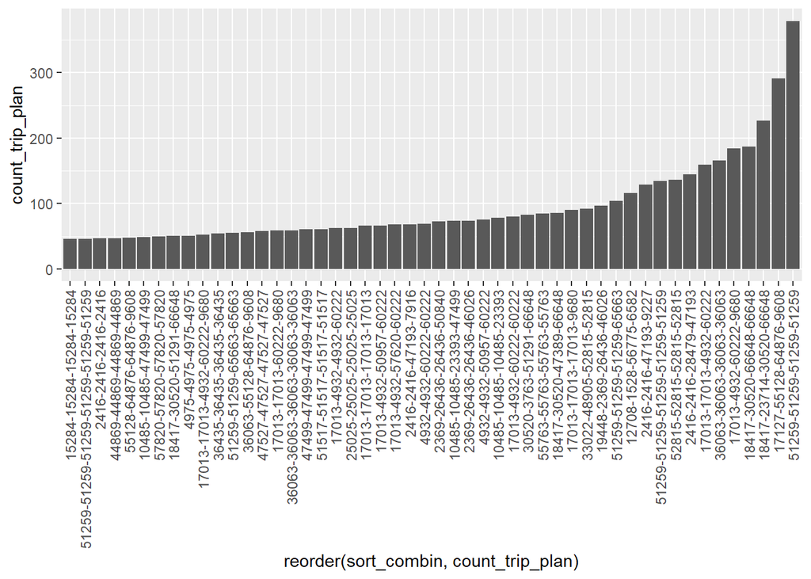

```r
train %>%
  group_by(utrip_id) %>%
  summarise(sort_combin = str_c(sort(city_id), collapse = '-'))%>%
  group_by(sort_combin) %>%
  summarise(count_trip_plan = n()) %>%
  arrange(desc(count_trip_plan)) %>%
  head(50)%>%
  ggplot(aes(x=reorder(sort_combin,count_trip_plan),y=count_trip_plan)) +
  geom_bar(stat = "identity") + theme(axis.text.x = element_text(angle = 90, vjust = 0.5, hjust=1))
```

```r
train %>%
  group_by(utrip_id) %>%
  summarise(sort_combin = str_c(city_id, collapse = '-'))%>%
  group_by(sort_combin) %>%
  summarise(count_trip_plan = n()) %>%
  arrange(desc(count_trip_plan))
```

```
## # A tibble: 200,701 x 2
##    sort_combin                   count_trip_plan
##    <chr>                                   <int>
##  1 51259-51259-51259-51259                   379
##  2 36063-36063-36063-36063                   166
##  3 64876-55128-9608-17127                    148
##  4 52815-52815-52815-52815                   136
##  5 51259-51259-51259-51259-51259             134
##  6 66648-18417-30520-66648                   123
##  7 17127-9608-55128-64876                     96
##  8 17013-9680-60222-4932                      89
##  9 66648-18417-30520-23714                    86
## 10 55763-55763-55763-55763                    85
## # ... with 200,691 more rows
```

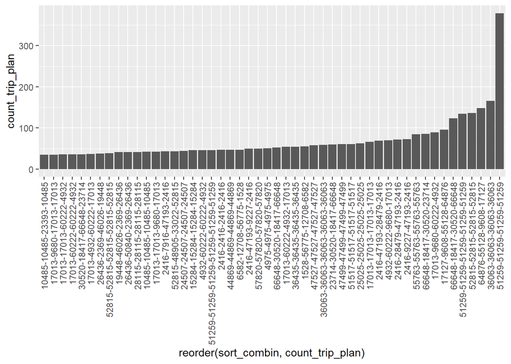

```r
train %>%
  group_by(utrip_id) %>%
  summarise(sort_combin = str_c(city_id, collapse = '-'))%>%
  group_by(sort_combin) %>%
  summarise(count_trip_plan = n()) %>%
  arrange(desc(count_trip_plan)) %>%
  head(50)%>%
  ggplot(aes(x=reorder(sort_combin,count_trip_plan),y=count_trip_plan)) +
  geom_bar(stat = "identity") + theme(axis.text.x = element_text(angle = 90, vjust = 0.5, hjust=1))
```

cityでなく国名で表示してみる(sortはわからんかった。sortしたデータフレームで同じことしたらええんか)

```r
train %>%
  group_by(utrip_id) %>%
  summarise(sort_combin = str_c(hotel_country, collapse = '-'))%>%
  group_by(sort_combin) %>%
  summarise(count_trip_plan = n()) %>%
  arrange(desc(count_trip_plan))%>%
  mutate(plan_number =str_c("plan_",row_number()))
```

```
## # A tibble: 28,708 x 3
##    sort_combin                                       count_trip_plan plan_number
##    <chr>                                                       <int> <chr>
##  1 Gondal-Gondal-Gondal-Gondal                                  9025 plan_1
##  2 Fook Island-Fook Island-Fook Island-Fook Island              7745 plan_2
##  3 Cobra Island-Cobra Island-Cobra Island-Cobra Isl~            7236 plan_3
##  4 Glubbdubdrib-Glubbdubdrib-Glubbdubdrib-Glubbdubd~            4926 plan_4
##  5 Borginia-Borginia-Borginia-Borginia                          4629 plan_5
##  6 Kangan-Kangan-Kangan-Kangan                                  4384 plan_6
##  7 Cobra Island-Cobra Island-Cobra Island-Cobra Isl~            4366 plan_7
##  8 Fook Island-Fook Island-Fook Island-Fook Island-~            3886 plan_8
##  9 Gondal-Gondal-Gondal-Gondal-Gondal                           3065 plan_9
## 10 Cobra Island-Cobra Island-Cobra Island-Cobra Isl~            2821 plan_10
## # ... with 28,698 more rows
```

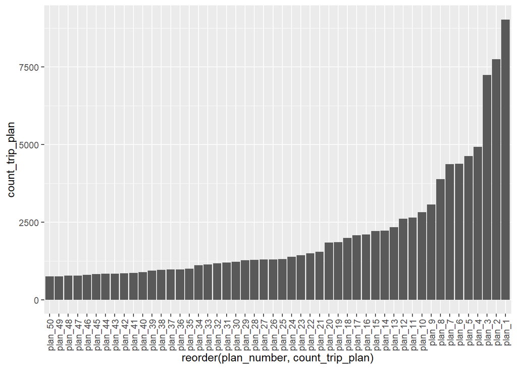

```r
train %>%
  group_by(utrip_id) %>%
  summarise(sort_combin = str_c(hotel_country, collapse = '-'))%>%
  group_by(sort_combin) %>%
  summarise(count_trip_plan = n()) %>%
  arrange(desc(count_trip_plan)) %>%
  mutate(rn =row_number(),
    plan_number =str_c("plan_",rn)) %>%
  head(50)%>%
  ggplot(aes(x=reorder(plan_number,count_trip_plan),y=count_trip_plan)) +
  geom_bar(stat = "identity") + theme(axis.text.x = element_text(angle = 90, vjust = 0.5, hjust=1))
```

```r
glimpse(train)
```

```
## Rows: 1,166,835
## Columns: 15
## $ X1             <dbl> 542546, 542547, 542548, 542549, 1061281, 1061282, 10612~
## $ user_id        <chr> "1000027", "1000027", "1000027", "1000027", "1000033", ~
## $ checkin        <date> 2016-08-13, 2016-08-14, 2016-08-16, 2016-08-18, 2016-0~
## $ checkout       <date> 2016-08-14, 2016-08-16, 2016-08-18, 2016-08-21, 2016-0~
## $ city_id        <chr> "8183", "15626", "60902", "30628", "38677", "52089", "2~
## $ device_class   <chr> "desktop", "desktop", "desktop", "desktop", "mobile", "~
## $ affiliate_id   <chr> "7168", "7168", "7168", "253", "359", "384", "384", "38~
## $ booker_country <chr> "Elbonia", "Elbonia", "Elbonia", "Elbonia", "Gondal", "~
## $ hotel_country  <chr> "Gondal", "Gondal", "Gondal", "Gondal", "Cobra Island",~
## $ utrip_id       <chr> "1000027_1", "1000027_1", "1000027_1", "1000027_1", "10~
## $ stay_days      <drtn> 1 days, 2 days, 2 days, 3 days, 2 days, 1 days, 2 days~
## $ joint          <chr> "Elbonia-Gondal", "Elbonia-Gondal", "Elbonia-Gondal", "~
## $ checkin_month  <dbl> 8, 8, 8, 8, 4, 4, 4, 4, 4, 6, 6, 6, 6, 6, 6, 6, 7, 7, 7~
## $ checkin_year   <dbl> 2016, 2016, 2016, 2016, 2016, 2016, 2016, 2016, 2016, 2~
## $ city_step      <int> 1, 2, 3, 4, 1, 2, 3, 4, 5, 1, 2, 3, 4, 5, 6, 7, 1, 2, 3~
```

```r
skim(train)
```

Data summary

| Name | train |
| --- | --- |
| Number of rows | 1166835 |
| Number of columns | 15 |
| _______________________ |  |
| Column type frequency: |  |
| character | 8 |
| Date | 2 |
| difftime | 1 |
| numeric | 4 |
| ________________________ |  |
| Group variables | None |

**Variable type: character**

| skim_variable | n_missing | complete_rate | min | max | empty | n_unique | whitespace |
| --- | --- | --- | --- | --- | --- | --- | --- |
| user_id | 0 | 1 | 2 | 7 | 0 | 200153 | 0 |
| city_id | 0 | 1 | 1 | 5 | 0 | 39901 | 0 |
| device_class | 0 | 1 | 6 | 7 | 0 | 3 | 0 |
| affiliate_id | 0 | 1 | 1 | 5 | 0 | 3254 | 0 |
| booker_country | 0 | 1 | 6 | 20 | 0 | 5 | 0 |
| hotel_country | 0 | 1 | 4 | 30 | 0 | 195 | 0 |
| utrip_id | 0 | 1 | 4 | 10 | 0 | 217686 | 0 |
| joint | 0 | 1 | 11 | 51 | 0 | 740 | 0 |

**Variable type: Date**

| skim_variable | n_missing | complete_rate | min | max | median | n_unique |
| --- | --- | --- | --- | --- | --- | --- |
| checkin | 0 | 1 | 2015-12-31 | 2017-02-27 | 2016-08-07 | 425 |
| checkout | 0 | 1 | 2016-01-01 | 2017-02-28 | 2016-08-08 | 425 |

**Variable type: difftime**

| skim_variable | n_missing | complete_rate | min | max | median | n_unique |
| --- | --- | --- | --- | --- | --- | --- |
| stay_days | 0 | 1 | 1 days | 30 days | 1 days | 30 |

**Variable type: numeric**

| skim_variable | n_missing | complete_rate | mean | sd | p0 | p25 | p50 | p75 | p100 | hist |
| --- | --- | --- | --- | --- | --- | --- | --- | --- | --- | --- |
| X1 | 0 | 1 | 583417.00 | 336836.40 | 0 | 291708.5 | 583417 | 875125.5 | 1166834 | ▇▇▇▇▇ |
| checkin_month | 0 | 1 | 7.02 | 2.79 | 1 | 5.0 | 8 | 9.0 | 12 | ▃▃▆▇▅ |
| checkin_year | 0 | 1 | 2016.04 | 0.20 | 2015 | 2016.0 | 2016 | 2016.0 | 2017 | ▁▁▇▁▁ |
| city_step | 0 | 1 | 3.56 | 2.38 | 1 | 2.0 | 3 | 5.0 | 48 | ▇▁▁▁▁ |

```r
skim(test)
```

Data summary

| Name | test |
| --- | --- |
| Number of rows | 378667 |
| Number of columns | 16 |
| _______________________ |  |
| Column type frequency: |  |
| character | 8 |
| Date | 2 |
| difftime | 1 |
| numeric | 5 |
| ________________________ |  |
| Group variables | None |

**Variable type: character**

| skim_variable | n_missing | complete_rate | min | max | empty | n_unique | whitespace |
| --- | --- | --- | --- | --- | --- | --- | --- |
| user_id | 0 | 1.00 | 2 | 7 | 0 | 68502 | 0 |
| device_class | 0 | 1.00 | 6 | 7 | 0 | 3 | 0 |
| affiliate_id | 0 | 1.00 | 1 | 5 | 0 | 2023 | 0 |
| booker_country | 0 | 1.00 | 6 | 20 | 0 | 5 | 0 |
| utrip_id | 0 | 1.00 | 4 | 10 | 0 | 70662 | 0 |
| city_id | 0 | 1.00 | 1 | 5 | 0 | 21305 | 0 |
| hotel_country | 70662 | 0.81 | 4 | 30 | 0 | 167 | 0 |
| joint | 70662 | 0.81 | 11 | 51 | 0 | 618 | 0 |

**Variable type: Date**

| skim_variable | n_missing | complete_rate | min | max | median | n_unique |
| --- | --- | --- | --- | --- | --- | --- |
| checkin | 0 | 1 | 2015-12-31 | 2017-02-27 | 2016-08-07 | 425 |
| checkout | 0 | 1 | 2016-01-01 | 2017-02-28 | 2016-08-09 | 425 |

**Variable type: difftime**

| skim_variable | n_missing | complete_rate | min | max | median | n_unique |
| --- | --- | --- | --- | --- | --- | --- |
| stay_days | 0 | 1 | 1 days | 30 days | 1 days | 29 |

**Variable type: numeric**

| skim_variable | n_missing | complete_rate | mean | sd | p0 | p25 | p50 | p75 | p100 | hist |
| --- | --- | --- | --- | --- | --- | --- | --- | --- | --- | --- |
| row_num | 0 | 1 | 3.54 | 2.33 | 1 | 2 | 3 | 5 | 44 | ▇▁▁▁▁ |
| total_rows | 0 | 1 | 6.08 | 2.70 | 4 | 4 | 5 | 7 | 44 | ▇▁▁▁▁ |
| checkin_month | 0 | 1 | 7.01 | 2.81 | 1 | 5 | 8 | 9 | 12 | ▃▃▆▇▅ |
| checkin_year | 0 | 1 | 2016.05 | 0.21 | 2015 | 2016 | 2016 | 2016 | 2017 | ▁▁▇▁▁ |
| city_step | 0 | 1 | 3.54 | 2.33 | 1 | 2 | 3 | 5 | 44 | ▇▁▁▁▁ |

```r
train %>% count(booker_country) %>% arrange(desc(n))
```

```
## # A tibble: 5 x 2
##   booker_country            n
##   <chr>                 <int>
## 1 Gondal               536036
## 2 The Devilfire Empire 286244
## 3 Elbonia              235344
## 4 Tcherkistan           80573
## 5 Bartovia              28638
```

```r
train %>% count(hotel_country)  %>% arrange(desc(n))
```

```
## # A tibble: 195 x 2
##    hotel_country               n
##    <chr>                   <int>
##  1 Cobra Island           137791
##  2 Fook Island            117717
##  3 Gondal                 104979
##  4 Glubbdubdrib            74840
##  5 Elbonia                 53965
##  6 Borginia                45629
##  7 Kangan                  44876
##  8 Bozatta                 40599
##  9 Alvonia                 34446
## 10 Holy Britannian Empire  30040
## # ... with 185 more rows
```

```r
train %>% count(city_id)  %>% arrange(desc(n))
```

```
## # A tibble: 39,901 x 2
##    city_id     n
##    <chr>   <int>
##  1 47499   11242
##  2 23921   10511
##  3 36063    9559
##  4 17013    9011
##  5 29319    8179
##  6 64876    7784
##  7 55128    7763
##  8 17127    6893
##  9 2416     6641
## 10 66648    6625
## # ... with 39,891 more rows
```

```r
train %>% count(device_class)  %>% arrange(desc(n))
```

```
## # A tibble: 3 x 2
##   device_class      n
##   <chr>         <int>
## 1 desktop      753860
## 2 mobile       331856
## 3 tablet        81119
```

```r
train %>% count(affiliate_id)  %>% arrange(desc(n))
```

```
## # A tibble: 3,254 x 2
##    affiliate_id      n
##    <chr>         <int>
##  1 9924         277775
##  2 359          171385
##  3 384           88137
##  4 9452          85476
##  5 4541          41504
##  6 8436          31275
##  7 10332         27309
##  8 3631          25606
##  9 9598          24329
## 10 8132          22254
## # ... with 3,244 more rows
```

```r
train %>% count(utrip_id)  %>% arrange(desc(n))
```

```
## # A tibble: 217,686 x 2
##    utrip_id       n
##    <chr>      <int>
##  1 3635431_3     48
##  2 2209265_10    45
##  3 433188_8      44
##  4 2209265_15    41
##  5 5231140_3     41
##  6 2899950_1     39
##  7 3422831_1     39
##  8 3878245_1     39
##  9 1380626_3     36
## 10 3611727_3     36
## # ... with 217,676 more rows
```

```r
train %>% count(stay_days)  %>% arrange(desc(n))
```

```
## # A tibble: 30 x 2
##    stay_days      n
##    <drtn>     <int>
##  1  1 days   674542
##  2  2 days   283720
##  3  3 days   124508
##  4  4 days    47791
##  5  5 days    18296
##  6  6 days     7791
##  7  7 days     6157
##  8  8 days     1498
##  9  9 days      761
## 10 10 days      603
## # ... with 20 more rows
```

メモ：  
やっぱりロングステイの深堀はしたいかも  
幸いな事に1か月以上とかはない様子

超ロングステイと結びつくというと、  
・特別な個性を持つ富豪ユーザー  
とか  
・長期滞在がやすい国とか  
最悪外れ値の可能性も

ココが固定できると予測とかイランくなってたすかる

```r
train %>% count(checkin_month)  %>% arrange(desc(n))
```

```
## # A tibble: 12 x 2
##    checkin_month      n
##            <dbl>  <int>
##  1             8 228144
##  2             7 168571
##  3             9 142213
##  4            10 106666
##  5             5  93022
##  6             6  91255
##  7             4  70851
##  8             2  59935
##  9            11  56183
## 10            12  51135
## 11             1  49717
## 12             3  49143
```

夏が多い  
海外も夏休みとかあんのかな  
しかし夏休みというと北半球  
南半球は12月のイメージだけど。  
そもそも北半球と南半球で旅行のオンシーズンってちがうの？  
国と長期休暇の違いが頭で結びついてないから調べる必要がありそう

あと、大学の休みとかなら海外なら秋入学とかもあるだろうし。

その国特有の休日祝日とかあるだろうし(旧正月には日本へ行きがち、みたいな)

ユーザーの特性を学生・社会人・とかにクラスタリングできないものか

# 1-アクセス国と、対称国の関係 （フランス人は京都がお好き、みたいな）

```r
train %>% count(booker_country) %>% arrange(desc(n))
```

```
## # A tibble: 5 x 2
##   booker_country            n
##   <chr>                 <int>
## 1 Gondal               536036
## 2 The Devilfire Empire 286244
## 3 Elbonia              235344
## 4 Tcherkistan           80573
## 5 Bartovia              28638
```

メモ：  
実在の国じゃないのね？

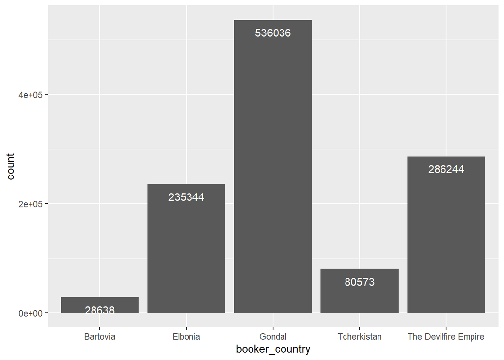

```r
train %>%
  ggplot(aes(x=booker_country)) +
  geom_bar(stat = 'count') +
  stat_count(aes(label = ..count..), geom = "text", vjust = 2, colour = "white")
```

メモ：  
数少ないところは予測モデル作る時に不均衡になりそうで怖い

ここは時間かけて確認したい

```r
train %>%
  mutate(joint = str_c(booker_country,'-',hotel_country))%>%
  group_by(joint)%>%
  summarise(coun = n())%>%
  arrange(desc(coun))
```

```
## # A tibble: 740 x 2
##    joint                              coun
##    <chr>                             <int>
##  1 Gondal-Gondal                     77574
##  2 Gondal-Fook Island                68302
##  3 Gondal-Cobra Island               53749
##  4 Gondal-Glubbdubdrib               47406
##  5 The Devilfire Empire-Cobra Island 46332
##  6 Elbonia-Cobra Island              32153
##  7 The Devilfire Empire-Borginia     30390
##  8 Gondal-Alvonia                    25606
##  9 Elbonia-Fook Island               23953
## 10 Elbonia-Elbonia                   22972
## # ... with 730 more rows
```

```r
top20 <- train %>%
  mutate(joint = str_c(booker_country,'-',hotel_country))%>%
  group_by(joint)%>%
  summarise(coun = n())%>%
  arrange(desc(coun))%>%
  head(20)
```

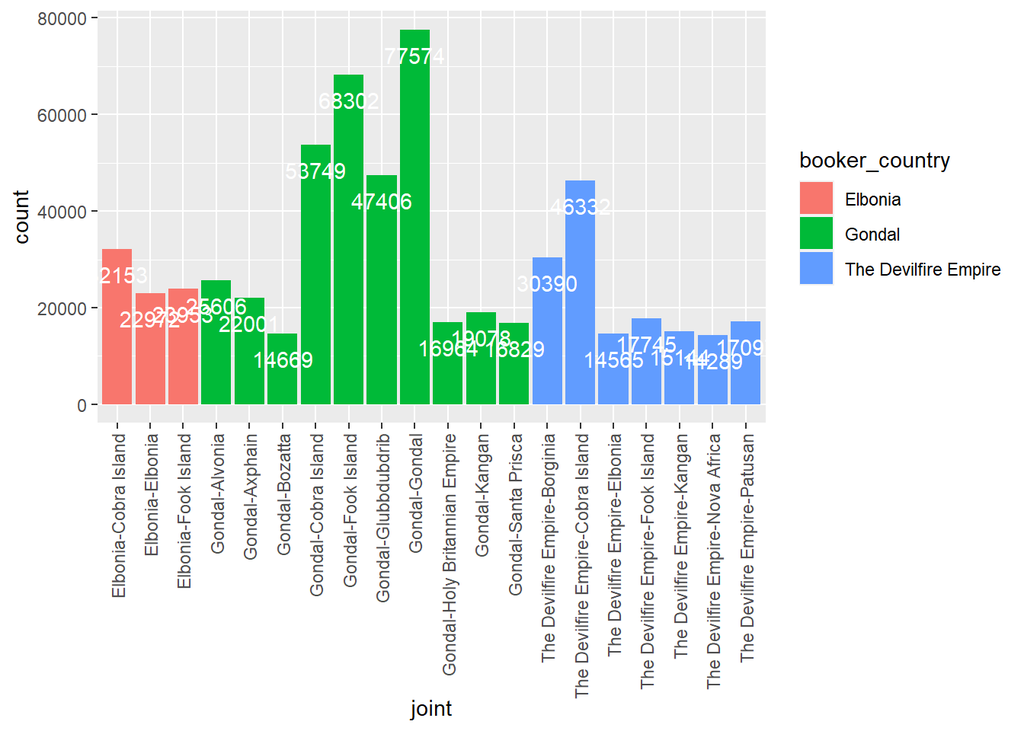

```r
train %>%

  mutate(joint = str_c(booker_country,'-',hotel_country))%>%
  filter(joint %in% unique(top20$joint))%>%
  ggplot(aes(x=joint,fill=booker_country)) +
  geom_bar(stat = 'count') +
  stat_count(aes(label = ..count..), geom = "text", vjust = 2, colour = "white")+
  theme(axis.text.x = element_text(angle = 90, vjust = 0.5, hjust=1))
```

メモ：  
gondalが多すぎ  
コレ全体数に締める割合で考えたらどうか？  
nestして実行？group byしてから条件付けで確率に変換？  
国別にして可視化したほうが処理も楽やし、確認しやすくていいかも

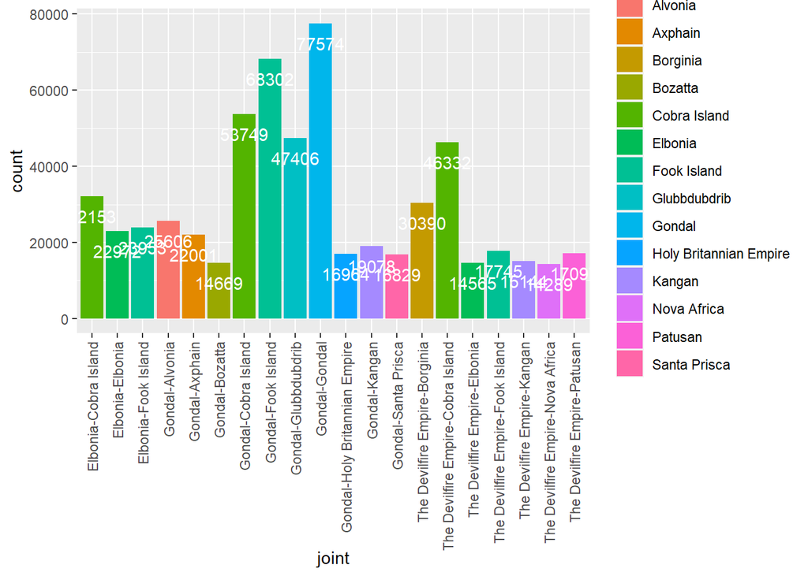

```r
train %>%
  mutate(joint = str_c(booker_country,'-',hotel_country))%>%
  filter(joint %in% unique(top20$joint))%>%
  ggplot(aes(x=joint,fill=hotel_country)) +
  geom_bar(stat = 'count') +
  stat_count(aes(label = ..count..), geom = "text", vjust = 2, colour = "white")+
  theme(axis.text.x = element_text(angle = 90, vjust = 0.5, hjust=1))
```

# 2-常連客がどの国、どの町を予約するか （ほとんど決定論的に決まるなら固定でいいやん？）

常連さんがわかるかも

```r
train %>%
  group_by(user_id) %>%
  summarise(coun=n()) %>%
  arrange(desc(coun))
```

```
## # A tibble: 200,153 x 2
##    user_id  coun
##    <chr>   <int>
##  1 2209265   172
##  2 870848    137
##  3 3635431   123
##  4 362194    102
##  5 5819402    94
##  6 1570474    79
##  7 4707321    76
##  8 433188     70
##  9 5054789    68
## 10 4615970    63
## # ... with 200,143 more rows
```

```r
train %>%
  group_by(user_id) %>%
  summarise(coun=n()) %>%
  arrange(desc(coun)) %>%
  mutate(rati = coun / sum(coun),
    cm = cumsum(rati),
         rn = row_number()
         )
```

```
## # A tibble: 200,153 x 5
##    user_id  coun      rati       cm    rn
##    <chr>   <int>     <dbl>    <dbl> <int>
##  1 2209265   172 0.000147  0.000147     1
##  2 870848    137 0.000117  0.000265     2
##  3 3635431   123 0.000105  0.000370     3
##  4 362194    102 0.0000874 0.000458     4
##  5 5819402    94 0.0000806 0.000538     5
##  6 1570474    79 0.0000677 0.000606     6
##  7 4707321    76 0.0000651 0.000671     7
##  8 433188     70 0.0000600 0.000731     8
##  9 5054789    68 0.0000583 0.000789     9
## 10 4615970    63 0.0000540 0.000843    10
## # ... with 200,143 more rows
```

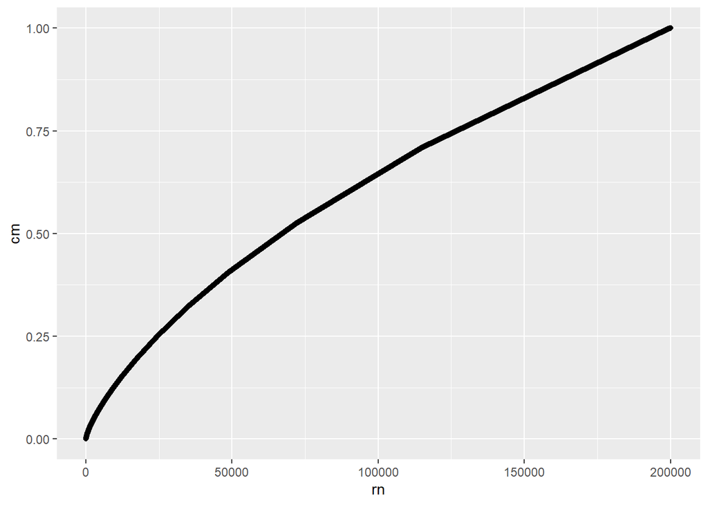

```r
train %>%
  group_by(user_id) %>%
  summarise(coun=n()) %>%
  arrange(desc(coun)) %>%
  mutate(rati = coun / sum(coun),
    cm = cumsum(rati),
         rn = row_number()
         ) %>%
  ggplot(aes(x=rn,y=cm)) +
  geom_point()
```

メモ：  
旅行好きをどの範囲からにしよう  
ABCランク分け的に上位25%くらい？  
にしてもユーザー数が多すぎなので絞ろう  
まずtop10人くらい

```r
trip_lover_10 <- train %>%
  group_by(user_id) %>%
  summarise(coun=n()) %>%
  filter(coun > 60) %>%
  arrange(desc(coun))


trip_lover_10
```

```
## # A tibble: 13 x 2
##    user_id  coun
##    <chr>   <int>
##  1 2209265   172
##  2 870848    137
##  3 3635431   123
##  4 362194    102
##  5 5819402    94
##  6 1570474    79
##  7 4707321    76
##  8 433188     70
##  9 5054789    68
## 10 4615970    63
## 11 5313305    63
## 12 4724963    61
## 13 901602     61
```

常連さんはどこに行ってるの？  
ボクはタイにいきたい

```r
train %>% filter(user_id %in% unique(trip_lover_10$user_id)) %>%
  group_by(user_id,hotel_country) %>%
  summarise(coun=n()) %>%
  arrange(user_id,desc(coun))
```

```
## # A tibble: 57 x 3
## # Groups:   user_id [13]
##    user_id hotel_country          coun
##    <chr>   <chr>                 <int>
##  1 1570474 Bozatta                  30
##  2 1570474 Elbonia                  14
##  3 1570474 Bultan                    9
##  4 1570474 Leutonia                  8
##  5 1570474 Gondal                    7
##  6 1570474 Robo-Hungarian Empire     5
##  7 1570474 Dawsbergen                4
##  8 1570474 Aslerfan                  2
##  9 2209265 The Devilfire Empire    129
## 10 2209265 Bozatta                  43
## # ... with 47 more rows
```

```r
train %>% filter(user_id %in% unique(trip_lover_10$user_id)) %>%
  group_by(user_id,city_id) %>%
  summarise(coun=n()) %>%
  arrange(user_id,desc(coun))
```

```
## # A tibble: 354 x 3
## # Groups:   user_id [13]
##    user_id city_id  coun
##    <chr>   <chr>   <int>
##  1 1570474 11857       3
##  2 1570474 61612       3
##  3 1570474 2748        2
##  4 1570474 37601       2
##  5 1570474 55763       2
##  6 1570474 10191       1
##  7 1570474 10359       1
##  8 1570474 11115       1
##  9 1570474 13097       1
## 10 1570474 13360       1
## # ... with 344 more rows
```

メモ：  
滞在日数とかでも深ぼりたい  
それは5でやる？

# 3-旅行目的区分とホテルの国、cityの結びつき （この目的のヒトはこの国行きやすいとか）

```r
train %>% names()
```

```
##  [1] "X1"             "user_id"        "checkin"        "checkout"
##  [5] "city_id"        "device_class"   "affiliate_id"   "booker_country"
##  [9] "hotel_country"  "utrip_id"       "stay_days"      "joint"
## [13] "checkin_month"  "checkin_year"   "city_step"
```

```r
train %>% group_by(utrip_id,user_id) %>% summarise(count=n()) %>% arrange(desc(count))
```

```
## # A tibble: 217,686 x 3
## # Groups:   utrip_id [217,686]
##    utrip_id   user_id count
##    <chr>      <chr>   <int>
##  1 3635431_3  3635431    48
##  2 2209265_10 2209265    45
##  3 433188_8   433188     44
##  4 2209265_15 2209265    41
##  5 5231140_3  5231140    41
##  6 2899950_1  2899950    39
##  7 3422831_1  3422831    39
##  8 3878245_1  3878245    39
##  9 1380626_3  1380626    36
## 10 3611727_3  3611727    36
## # ... with 217,676 more rows
```

```r
train %>% filter(user_id == "433188") %>% count(utrip_id)
```

```
## # A tibble: 5 x 2
##   utrip_id      n
## * <chr>     <int>
## 1 433188_10    11
## 2 433188_4      4
## 3 433188_6      5
## 4 433188_8     44
## 5 433188_9      6
```

ひょっとしたらidの欠けているところがtestに来るのでは？とおもった。

```r
test %>% filter(user_id == "433188") %>% count(utrip_id)
```

```
## # A tibble: 0 x 2
## # ... with 2 variables: utrip_id <chr>, n <int>
```

ここにはないけどプライベートデータにはあるとか？

```r
skim(train)
```

Data summary

| Name | train |
| --- | --- |
| Number of rows | 1166835 |
| Number of columns | 15 |
| _______________________ |  |
| Column type frequency: |  |
| character | 8 |
| Date | 2 |
| difftime | 1 |
| numeric | 4 |
| ________________________ |  |
| Group variables | None |

**Variable type: character**

| skim_variable | n_missing | complete_rate | min | max | empty | n_unique | whitespace |
| --- | --- | --- | --- | --- | --- | --- | --- |
| user_id | 0 | 1 | 2 | 7 | 0 | 200153 | 0 |
| city_id | 0 | 1 | 1 | 5 | 0 | 39901 | 0 |
| device_class | 0 | 1 | 6 | 7 | 0 | 3 | 0 |
| affiliate_id | 0 | 1 | 1 | 5 | 0 | 3254 | 0 |
| booker_country | 0 | 1 | 6 | 20 | 0 | 5 | 0 |
| hotel_country | 0 | 1 | 4 | 30 | 0 | 195 | 0 |
| utrip_id | 0 | 1 | 4 | 10 | 0 | 217686 | 0 |
| joint | 0 | 1 | 11 | 51 | 0 | 740 | 0 |

**Variable type: Date**

| skim_variable | n_missing | complete_rate | min | max | median | n_unique |
| --- | --- | --- | --- | --- | --- | --- |
| checkin | 0 | 1 | 2015-12-31 | 2017-02-27 | 2016-08-07 | 425 |
| checkout | 0 | 1 | 2016-01-01 | 2017-02-28 | 2016-08-08 | 425 |

**Variable type: difftime**

| skim_variable | n_missing | complete_rate | min | max | median | n_unique |
| --- | --- | --- | --- | --- | --- | --- |
| stay_days | 0 | 1 | 1 days | 30 days | 1 days | 30 |

**Variable type: numeric**

| skim_variable | n_missing | complete_rate | mean | sd | p0 | p25 | p50 | p75 | p100 | hist |
| --- | --- | --- | --- | --- | --- | --- | --- | --- | --- | --- |
| X1 | 0 | 1 | 583417.00 | 336836.40 | 0 | 291708.5 | 583417 | 875125.5 | 1166834 | ▇▇▇▇▇ |
| checkin_month | 0 | 1 | 7.02 | 2.79 | 1 | 5.0 | 8 | 9.0 | 12 | ▃▃▆▇▅ |
| checkin_year | 0 | 1 | 2016.04 | 0.20 | 2015 | 2016.0 | 2016 | 2016.0 | 2017 | ▁▁▇▁▁ |
| city_step | 0 | 1 | 3.56 | 2.38 | 1 | 2.0 | 3 | 5.0 | 48 | ▇▁▁▁▁ |

```r
train %>% group_by(utrip_id,hotel_country) %>% summarise(count=n()) %>% arrange(desc(utrip_id,count))
```

```
## # A tibble: 307,828 x 3
## # Groups:   utrip_id [217,686]
##    utrip_id hotel_country count
##    <chr>    <chr>         <int>
##  1 999944_1 Glubbdubdrib      4
##  2 999855_1 Fook Island      15
##  3 999842_1 Alvonia           1
##  4 999842_1 Glubbdubdrib      3
##  5 999839_1 Cobra Island      4
##  6 999776_1 Novistrana        4
##  7 999755_1 Fook Island       2
##  8 999755_1 Gondal            2
##  9 999735_1 Carpathia         1
## 10 999735_1 Gondal            4
## # ... with 307,818 more rows
```

```r
train %>% group_by(utrip_id,hotel_country,city_id) %>% summarise(count=n()) %>% arrange(desc(count))
```

```
## # A tibble: 1,034,662 x 4
## # Groups:   utrip_id, hotel_country [307,828]
##    utrip_id   hotel_country        city_id count
##    <chr>      <chr>                <chr>   <int>
##  1 433188_8   Elbonia              26951      44
##  2 3611727_3  Oceania              51259      36
##  3 362194_12  Bahavia              43540      36
##  4 1481929_2  Kumbolaland          49486      34
##  5 2209265_10 The Devilfire Empire 58974      33
##  6 5222523_2  Gondal               36686      31
##  7 2209265_15 The Devilfire Empire 9723       27
##  8 3635431_3  Gondal               36063      26
##  9 2985574_2  Aldovia              52815      24
## 10 721496_1   Dawsbergen           21929      24
## # ... with 1,034,652 more rows
```

# デバイスクラスでみてみる

# 4-チェックイン・チェックアウトから、平均滞在期間と町、国の関係

# 5-滞在期間と、予約者の国の関係(バケーション取りやすいとか？裏山)